# 2022.10.22 作业

## 王晨宇 2100010654

### 首先读入数据，对数据的格式进行规范化

```python
import os
import sys

import numpy as np
from numpy.random import randn
from pandas import Series, DataFrame
import pandas as pd
import matplotlib.pyplot as plt

from datetime import datetime
import calendar
from myfunctions import *

from scipy import optimize,stats

plt.rc('figure', figsize=(10, 6))
np.set_printoptions(precision=4)
pd.options.display.float_format='{:.4f}'.format
```

### 选取了股票指数和债券指数各三个

```python
stocks=['000001.SH','000002.SH','000003.SH']
bonds=['000012.SH','000013.SH','000022.SH']
```

```python
data1_daily=pd.read_csv('/Users/vampire/Desktop/Peking University/金融数据分析导论/data from tushare/index_daily.csv',index_col=0)
data1_daily=data1_daily[np.isin(data1_daily['ts_code'],stocks+bonds)]
data1_daily['trade_date']=pd.to_datetime(data1_daily['trade_date'])
data1_daily.set_index('trade_date',inplace=True)
data1_daily['vary']=data1_daily['pct_chg']/100+1
data1_daily
```

| trade_date | ts_code | close | open | high | low | pre_close | change | pct_chg | vol | amount | vary |
| --- | --- | --- | --- | --- | --- | --- | --- | --- | --- | --- | --- |
| 1990-12-19 | 000001.SH | 99.9800 | 96.0500 | 99.9800 | 95.7900 | 100.0000 | -0.0200 | -0.0200 | 1260.0000 | 494.3110 | 0.9998 |
| 1990-12-20 | 000001.SH | 104.3900 | 104.3000 | 104.3900 | 99.9800 | 99.9800 | 4.4100 | 4.4109 | 197.0000 | 84.9920 | 1.0441 |
| 1990-12-21 | 000001.SH | 109.1300 | 109.0700 | 109.1300 | 103.7300 | 104.3900 | 4.7400 | 4.5407 | 28.0000 | 16.0960 | 1.0454 |
| 1990-12-24 | 000001.SH | 114.5500 | 113.5700 | 114.5500 | 109.1300 | 109.1300 | 5.4200 | 4.9666 | 32.0000 | 31.0630 | 1.0497 |
| 1990-12-25 | 000001.SH | 120.2500 | 120.0900 | 120.2500 | 114.5500 | 114.5500 | 5.7000 | 4.9760 | 15.0000 | 6.5100 | 1.0498 |
| ... | ... | ... | ... | ... | ... | ... | ... | ... | ... | ... | ... |
| 2020-09-21 | 000022.SH | 210.3873 | 210.3890 | 210.3950 | 210.3760 | 210.3145 | 0.0728 | 0.0346 | 1043550.0000 | 1027076.5550 | 1.0003 |
| 2020-09-22 | 000022.SH | 210.3812 | 210.4140 | 210.4400 | 210.3810 | 210.3873 | -0.0061 | -0.0029 | 1109000.0000 | 1092808.0990 | 1.0000 |
| 2020-09-23 | 000022.SH | 210.3716 | 210.4130 | 210.4220 | 210.3690 | 210.3812 | -0.0096 | -0.0046 | 663130.0000 | 649397.0140 | 1.0000 |
| 2020-09-24 | 000022.SH | 210.3616 | 210.3990 | 210.3990 | 210.3440 | 210.3716 | -0.0100 | -0.0048 | 670860.0000 | 651150.6190 | 1.0000 |
| 2020-09-25 | 000022.SH | 209.9920 | 210.3870 | 210.3880 | 209.9210 | 210.3616 | -0.3696 | -0.1757 | 959610.0000 | 780175.0310 | 0.9982 |

34645 rows × 11 columns

### 提取数据中的收益率，按日期分组计算日、月、季度、年收益率以及收益率分布特征指标

```python
rate1_daily=DataFrame(data1_daily['ts_code'])
rate1_daily['rate_daily']=data1_daily['vary']
rate1_daily.reset_index(inplace=True)
rate1_daily.set_index(['trade_date','ts_code'],inplace=True)
rate1_daily=rate1_daily.unstack()
rate1_daily.columns=rate1_daily.columns.map(lambda x:x[1])
rate1_daily=pd.concat([rate1_daily,rate1_daily.describe()],axis=0)
rate1_daily.drop('count',inplace=True)
rate1_daily-=1
rate1_daily.loc['std']+=1
rate1_daily
```

|  | 000001.SH | 000002.SH | 000003.SH | 000012.SH | 000013.SH | 000022.SH |
| --- | --- | --- | --- | --- | --- | --- |
| 1990-12-19 00:00:00 | -0.0002 | -0.0002 | NaN | NaN | NaN | NaN |
| 1990-12-20 00:00:00 | 0.0441 | 0.0441 | NaN | NaN | NaN | NaN |
| 1990-12-21 00:00:00 | 0.0454 | 0.0454 | NaN | NaN | NaN | NaN |
| 1990-12-24 00:00:00 | 0.0497 | 0.0497 | NaN | NaN | NaN | NaN |
| 1990-12-25 00:00:00 | 0.0498 | 0.0498 | NaN | NaN | NaN | NaN |
| ... | ... | ... | ... | ... | ... | ... |
| min | -0.1639 | -0.1683 | -0.1282 | -0.0138 | -0.0192 | -0.0114 |
| 25% | -0.0072 | -0.0072 | -0.0074 | -0.0001 | -0.0000 | -0.0000 |
| 50% | 0.0006 | 0.0006 | 0.0002 | 0.0001 | 0.0002 | 0.0002 |
| 75% | 0.0084 | 0.0084 | 0.0078 | 0.0004 | 0.0005 | 0.0005 |
| max | 1.0527 | 1.1068 | 0.2465 | 0.0102 | 0.0169 | 0.0204 |

7780 rows × 6 columns

### rate1_daily即为股票指数和债券指数的日收益率以及分布特征指标

```python
rate1_monthly=DataFrame(data1_daily.groupby('ts_code')['vary'].resample('M').apply(np.prod))
rate1_monthly['rate_monthly']=rate1_monthly['vary']
rate1_monthly.drop('vary',axis=1,inplace=True)
rate1_monthly=rate1_monthly.unstack(level=0)
rate1_monthly.columns=rate1_monthly.columns.map(lambda x:x[1])
rate1_monthly=pd.concat([rate1_monthly,rate1_monthly.describe()],axis=0)
rate1_monthly.drop('count',inplace=True)
rate1_monthly-=1
rate1_monthly.loc['std']+=1
rate1_monthly
```

|  | 000001.SH | 000002.SH | 000003.SH | 000012.SH | 000013.SH | 000022.SH |
| --- | --- | --- | --- | --- | --- | --- |
| 1990-12-31 00:00:00 | 0.2761 | 0.2761 | NaN | NaN | NaN | NaN |
| 1991-01-31 00:00:00 | 0.0185 | 0.0185 | NaN | NaN | NaN | NaN |
| 1991-02-28 00:00:00 | 0.0234 | 0.0234 | NaN | NaN | NaN | NaN |
| 1991-03-31 00:00:00 | -0.0964 | -0.0964 | NaN | NaN | NaN | NaN |
| 1991-04-30 00:00:00 | -0.0520 | -0.0520 | NaN | NaN | NaN | NaN |
| ... | ... | ... | ... | ... | ... | ... |
| min | -0.3115 | -0.3168 | -0.3336 | -0.0564 | -0.0691 | -0.0141 |
| 25% | -0.0457 | -0.0455 | -0.0488 | 0.0006 | 0.0013 | 0.0020 |
| 50% | 0.0063 | 0.0064 | -0.0005 | 0.0029 | 0.0044 | 0.0047 |
| 75% | 0.0502 | 0.0514 | 0.0527 | 0.0049 | 0.0072 | 0.0075 |
| max | 1.7723 | 1.8951 | 0.7160 | 0.0226 | 0.0450 | 0.0413 |

390 rows × 6 columns

### rate1_monthly即为股票指数和债券指数的月收益率以及分布特征指标

```python
rate1_seasonly=DataFrame(data1_daily.groupby('ts_code')['vary'].resample('Q').apply(np.prod))
rate1_seasonly['rate_seasonly']=rate1_seasonly['vary']
rate1_seasonly.drop('vary',axis=1,inplace=True)
rate1_seasonly=rate1_seasonly.unstack(level=0)
rate1_seasonly.columns=rate1_seasonly.columns.map(lambda x:x[1])
rate1_seasonly=pd.concat([rate1_seasonly,rate1_seasonly.describe()],axis=0)
rate1_seasonly.drop('count',inplace=True)
rate1_seasonly-=1
rate1_seasonly.loc['std']+=1
rate1_seasonly
```

|  | 000001.SH | 000002.SH | 000003.SH | 000012.SH | 000013.SH | 000022.SH |
| --- | --- | --- | --- | --- | --- | --- |
| 1990-12-31 00:00:00 | 0.2761 | 0.2761 | NaN | NaN | NaN | NaN |
| 1991-03-31 00:00:00 | -0.0581 | -0.0581 | NaN | NaN | NaN | NaN |
| 1991-06-30 00:00:00 | 0.1445 | 0.1445 | NaN | NaN | NaN | NaN |
| 1991-09-30 00:00:00 | 0.3152 | 0.3152 | NaN | NaN | NaN | NaN |
| 1991-12-31 00:00:00 | 0.6181 | 0.6181 | NaN | NaN | NaN | NaN |
| ... | ... | ... | ... | ... | ... | ... |
| min | -0.4104 | -0.4066 | -0.4598 | -0.0349 | -0.0429 | -0.0160 |
| 25% | -0.0677 | -0.0706 | -0.0958 | 0.0031 | 0.0030 | 0.0069 |
| 50% | 0.0099 | 0.0104 | 0.0119 | 0.0083 | 0.0125 | 0.0142 |
| 75% | 0.0988 | 0.0994 | 0.1081 | 0.0127 | 0.0207 | 0.0197 |
| max | 2.1245 | 2.2866 | 1.2074 | 0.0515 | 0.0870 | 0.0603 |

136 rows × 6 columns

### rate1_seasonly即为股票指数和债券指数的季度收益率以及分布特征指标

```python
rate1_yearly=DataFrame(data1_daily.groupby('ts_code')['vary'].resample('Y').apply(np.prod))
rate1_yearly['rate_seasonly']=rate1_yearly['vary']
rate1_yearly.drop('vary',axis=1,inplace=True)
rate1_yearly=rate1_yearly.unstack(level=0)
rate1_yearly.columns=rate1_yearly.columns.map(lambda x:x[1])
rate1_yearly=pd.concat([rate1_yearly,rate1_yearly.describe()],axis=0)
rate1_yearly.drop('count',inplace=True)
rate1_yearly-=1
rate1_yearly.loc['std']+=1
rate1_yearly
```

|  | 000001.SH | 000002.SH | 000003.SH | 000012.SH | 000013.SH | 000022.SH |
| --- | --- | --- | --- | --- | --- | --- |
| 1990-12-31 00:00:00 | 0.2761 | 0.2761 | NaN | NaN | NaN | NaN |
| 1991-12-31 00:00:00 | 1.2941 | 1.2941 | NaN | NaN | NaN | NaN |
| 1992-12-31 00:00:00 | 1.6657 | 1.7867 | -0.3378 | NaN | NaN | NaN |
| 1993-12-31 00:00:00 | 0.0684 | 0.0392 | 0.5577 | NaN | NaN | NaN |
| 1994-12-31 00:00:00 | -0.2230 | -0.2123 | -0.3912 | NaN | NaN | NaN |
| 1995-12-31 00:00:00 | -0.1429 | -0.1232 | -0.2406 | NaN | NaN | NaN |
| 1996-12-31 00:00:00 | 0.6514 | 0.6603 | 0.4054 | NaN | NaN | NaN |
| 1997-12-31 00:00:00 | 0.3022 | 0.3178 | -0.1663 | NaN | NaN | NaN |
| 1998-12-31 00:00:00 | -0.0397 | -0.0309 | -0.4862 | NaN | NaN | NaN |
| 1999-12-31 00:00:00 | 0.1917 | 0.1904 | 0.3204 | NaN | NaN | NaN |
| 2000-12-31 00:00:00 | 0.5173 | 0.5100 | 1.3621 | NaN | NaN | NaN |
| 2001-12-31 00:00:00 | -0.2062 | -0.2189 | 0.9155 | NaN | NaN | NaN |
| 2002-12-31 00:00:00 | -0.1752 | -0.1713 | -0.3383 | NaN | NaN | NaN |
| 2003-12-31 00:00:00 | 0.1027 | 0.1057 | -0.0755 | -0.0052 | -0.0427 | NaN |
| 2004-12-31 00:00:00 | -0.1540 | -0.1523 | -0.2791 | -0.0381 | -0.0407 | NaN |
| 2005-12-31 00:00:00 | -0.0833 | -0.0821 | -0.1803 | 0.1406 | 0.2408 | NaN |
| 2006-12-31 00:00:00 | 1.3043 | 1.3057 | 1.0982 | 0.0214 | 0.0077 | NaN |
| 2007-12-31 00:00:00 | 0.9666 | 0.9614 | 1.8123 | -0.0046 | -0.0549 | NaN |
| 2008-12-31 00:00:00 | -0.6539 | -0.6538 | -0.6969 | 0.0940 | 0.1711 | 0.1533 |
| 2009-12-31 00:00:00 | 0.7998 | 0.7980 | 1.2756 | 0.0087 | 0.0068 | 0.0182 |
| 2010-12-31 00:00:00 | -0.1431 | -0.1446 | 0.2058 | 0.0321 | 0.0741 | 0.0849 |
| 2011-12-31 00:00:00 | -0.2168 | -0.2164 | -0.2927 | 0.0405 | 0.0350 | 0.0337 |
| 2012-12-31 00:00:00 | 0.0317 | 0.0312 | 0.1377 | 0.0335 | 0.0749 | 0.0786 |
| 2013-12-31 00:00:00 | -0.0675 | -0.0680 | 0.0356 | 0.0275 | 0.0436 | 0.0290 |
| 2014-12-31 00:00:00 | 0.5288 | 0.5307 | 0.1464 | 0.0442 | 0.0873 | 0.0750 |
| 2015-12-31 00:00:00 | 0.0941 | 0.0929 | 0.4665 | 0.0609 | 0.0884 | 0.0903 |
| 2016-12-31 00:00:00 | -0.1231 | -0.1227 | -0.1984 | 0.0339 | 0.0605 | 0.0478 |
| 2017-12-31 00:00:00 | 0.0656 | 0.0658 | 0.0000 | 0.0067 | 0.0213 | 0.0137 |
| 2018-12-31 00:00:00 | -0.2459 | -0.2460 | -0.2070 | 0.0562 | 0.0574 | 0.0572 |
| 2019-12-31 00:00:00 | 0.2233 | 0.2241 | -0.0525 | 0.0435 | 0.0574 | 0.0547 |
| 2020-12-31 00:00:00 | 0.1387 | 0.1391 | -0.0520 | 0.0321 | 0.0362 | 0.0351 |
| 2021-12-31 00:00:00 | 0.0480 | 0.0477 | 0.1741 | NaN | NaN | NaN |
| 2022-12-31 00:00:00 | -0.1560 | -0.1560 | 0.0321 | NaN | NaN | NaN |
| mean | 0.2012 | 0.2054 | 0.1597 | 0.0349 | 0.0514 | 0.0593 |
| std | 0.5136 | 0.5244 | 0.5891 | 0.0393 | 0.0720 | 0.0378 |
| min | -0.6539 | -0.6538 | -0.6969 | -0.0381 | -0.0549 | 0.0137 |
| 25% | -0.1431 | -0.1446 | -0.2238 | 0.0119 | 0.0111 | 0.0337 |
| 50% | 0.0656 | 0.0477 | 0.0000 | 0.0328 | 0.0505 | 0.0547 |
| 75% | 0.3022 | 0.3178 | 0.3629 | 0.0440 | 0.0747 | 0.0786 |
| max | 1.6657 | 1.7867 | 1.8123 | 0.1406 | 0.2408 | 0.1533 |

### rate1_yearly即为股票指数和债券指数的年收益率以及分布特征指标

### 接下来读入商品指数和汇率指数数据，并规范化

```python
data2_daily=pd.read_csv('/Users/vampire/Desktop/Peking University/金融数据分析导论/汇率和商品指数.csv',skiprows=[0,1,2])
data2_daily['trade_date']=pd.to_datetime(data2_daily['Date'])
data2_daily.set_index('trade_date',inplace=True)
data2_daily.drop('Date',axis=1,inplace=True)
data2_daily.astype(float)
data2_daily+=1
data2_daily=data2_daily/data2_daily.shift()
data2_daily.dropna(how='all',inplace=True)
data2_daily
```

| trade_date | APFI.WI | CRFI.WI | CIFI.WI | ENFI.WI | JJRI.WI | NFFI.WI | CCFI.WI | SOFI.WI | OOFI.WI | NMFI.WI | NMBM.WI | USDX.FX | CNYX.CNI |
| --- | --- | --- | --- | --- | --- | --- | --- | --- | --- | --- | --- | --- | --- |
| 2000-01-05 | NaN | 1.0009 | 1.0042 | NaN | NaN | 0.9882 | 0.9886 | NaN | 1.0013 | NaN | NaN | 0.9991 | NaN |
| 2000-01-06 | NaN | 0.9966 | 1.0031 | NaN | NaN | 1.0060 | 1.0059 | NaN | 0.9991 | NaN | NaN | 1.0033 | NaN |
| 2000-01-07 | NaN | 0.9837 | 1.0078 | NaN | NaN | 1.0015 | 1.0017 | NaN | 1.0036 | NaN | NaN | 1.0015 | NaN |
| 2000-01-10 | NaN | 1.0000 | 1.0000 | NaN | NaN | 1.0000 | 1.0000 | NaN | 1.0000 | NaN | NaN | 1.0019 | NaN |
| 2000-01-11 | NaN | 1.0000 | 1.0000 | NaN | NaN | 1.0000 | 1.0000 | NaN | 1.0000 | NaN | NaN | 0.9958 | NaN |
| ... | ... | ... | ... | ... | ... | ... | ... | ... | ... | ... | ... | ... | ... |
| 2022-10-19 | 1.0065 | 0.9997 | 0.9900 | 0.9782 | 0.9965 | 1.0041 | 0.9972 | 0.9949 | 1.0067 | 0.9976 | 0.9969 | 1.0078 | 0.9969 |
| 2022-10-20 | 0.9998 | 1.0008 | 1.0009 | 1.0319 | 0.9807 | 1.0097 | 0.9998 | 0.9878 | 1.0007 | 0.9932 | 0.9995 | 0.9993 | 0.9999 |
| 2022-10-21 | 0.9969 | 1.0076 | 0.9921 | 0.9825 | 1.0089 | 0.9889 | 0.9956 | 0.9986 | 0.9960 | 1.0008 | 0.9918 | 0.9914 | 1.0001 |
| 2022-10-24 | 0.9861 | 1.0012 | 0.9990 | 1.0025 | 1.0011 | 1.0169 | 1.0028 | 0.9976 | 0.9910 | 1.0166 | 0.9991 | 1.0014 | 0.9944 |
| 2022-10-25 | 1.0018 | 0.9922 | 0.9926 | 1.0083 | 0.9816 | 1.0013 | 0.9969 | 0.9937 | 1.0065 | 1.0055 | 0.9853 | 1.0000 | 0.9936 |

5525 rows × 13 columns

```python
rate2_daily=pd.concat([data2_daily,data2_daily.describe()],axis=0)
rate2_daily.drop('count',inplace=True)
rate2_daily-=1
rate2_daily.loc['std']+=1
rate2_daily
```

|  | APFI.WI | CRFI.WI | CIFI.WI | ENFI.WI | JJRI.WI | NFFI.WI | CCFI.WI | SOFI.WI | OOFI.WI | NMFI.WI | NMBM.WI | USDX.FX | CNYX.CNI |
| --- | --- | --- | --- | --- | --- | --- | --- | --- | --- | --- | --- | --- | --- |
| 2000-01-05 00:00:00 | NaN | 0.0009 | 0.0042 | NaN | NaN | -0.0118 | -0.0114 | NaN | 0.0013 | NaN | NaN | -0.0009 | NaN |
| 2000-01-06 00:00:00 | NaN | -0.0034 | 0.0031 | NaN | NaN | 0.0060 | 0.0059 | NaN | -0.0009 | NaN | NaN | 0.0033 | NaN |
| 2000-01-07 00:00:00 | NaN | -0.0163 | 0.0078 | NaN | NaN | 0.0015 | 0.0017 | NaN | 0.0036 | NaN | NaN | 0.0015 | NaN |
| 2000-01-10 00:00:00 | NaN | 0.0000 | 0.0000 | NaN | NaN | 0.0000 | 0.0000 | NaN | 0.0000 | NaN | NaN | 0.0019 | NaN |
| 2000-01-11 00:00:00 | NaN | 0.0000 | 0.0000 | NaN | NaN | 0.0000 | 0.0000 | NaN | 0.0000 | NaN | NaN | -0.0042 | NaN |
| ... | ... | ... | ... | ... | ... | ... | ... | ... | ... | ... | ... | ... | ... |
| min | -0.1258 | -0.4098 | -0.0688 | -0.1628 | -0.0986 | -0.0712 | -0.0512 | -0.0592 | -0.0584 | -0.0888 | -0.1031 | -0.0316 | -0.0179 |
| 25% | -0.0070 | -0.0033 | -0.0075 | -0.0066 | -0.0076 | -0.0063 | -0.0058 | -0.0046 | -0.0054 | -0.0056 | -0.0062 | -0.0027 | -0.0011 |
| 50% | -0.0006 | 0.0000 | 0.0002 | 0.0000 | -0.0002 | 0.0005 | 0.0003 | 0.0000 | 0.0003 | 0.0003 | -0.0003 | 0.0000 | 0.0001 |
| 75% | 0.0062 | 0.0033 | 0.0082 | 0.0073 | 0.0074 | 0.0072 | 0.0066 | 0.0045 | 0.0063 | 0.0060 | 0.0060 | 0.0027 | 0.0013 |
| max | 0.1291 | 0.6808 | 0.0756 | 0.1193 | 0.0773 | 0.0764 | 0.0692 | 0.0598 | 0.0605 | 0.0677 | 0.0734 | 0.0598 | 0.0123 |

5532 rows × 13 columns

### rate2_daily即为商品指数和汇率指数的日收益率以及分布特征指标

```python
rate2_monthly=data2_daily.resample('M').apply(np.prod)
rate2_monthly=pd.concat([rate2_monthly,rate2_monthly.describe()],axis=0)
rate2_monthly.drop('count',inplace=True)
rate2_monthly-=1
rate2_monthly.loc['std']+=1
rate2_monthly.tail(10)
```

|  | APFI.WI | CRFI.WI | CIFI.WI | ENFI.WI | JJRI.WI | NFFI.WI | CCFI.WI | SOFI.WI | OOFI.WI | NMFI.WI | NMBM.WI | USDX.FX | CNYX.CNI |
| --- | --- | --- | --- | --- | --- | --- | --- | --- | --- | --- | --- | --- | --- |
| 2022-08-31 00:00:00 | 0.0526 | 0.0371 | -0.0446 | 0.0560 | -0.0686 | 0.0055 | -0.0212 | -0.0058 | 0.0027 | -0.0148 | -0.0436 | 0.0266 | -0.0074 |
| 2022-09-30 00:00:00 | -0.0347 | -0.0044 | 0.0473 | -0.1502 | 0.0538 | -0.0034 | -0.0092 | -0.0710 | -0.0544 | 0.0334 | 0.0048 | 0.0317 | -0.0122 |
| 2022-10-31 00:00:00 | -0.0080 | 0.0336 | -0.0761 | 0.0307 | -0.0714 | 0.0192 | -0.0166 | -0.0121 | 0.0245 | 0.0032 | -0.0926 | -0.0013 | -0.0196 |
| mean | 0.0002 | -0.0001 | 0.0026 | 0.0033 | 0.0001 | 0.0065 | 0.0049 | -0.0013 | 0.0035 | 0.0017 | -0.0012 | 0.0006 | 0.0007 |
| std | 0.0382 | 0.0330 | 0.0771 | 0.0664 | 0.0602 | 0.0631 | 0.0579 | 0.0429 | 0.0508 | 0.0452 | 0.0472 | 0.0227 | 0.0086 |
| min | -0.1145 | -0.1321 | -0.3048 | -0.3787 | -0.2950 | -0.3840 | -0.3479 | -0.1187 | -0.1941 | -0.1780 | -0.2081 | -0.0615 | -0.0314 |
| 25% | 0.0000 | -0.0185 | -0.0444 | -0.0252 | -0.0204 | -0.0301 | -0.0309 | -0.0204 | -0.0288 | -0.0090 | -0.0136 | -0.0136 | 0.0000 |
| 50% | 0.0000 | 0.0016 | -0.0013 | 0.0000 | 0.0000 | 0.0067 | 0.0022 | 0.0000 | 0.0022 | 0.0000 | 0.0000 | 0.0006 | 0.0000 |
| 75% | 0.0000 | 0.0184 | 0.0510 | 0.0354 | 0.0076 | 0.0381 | 0.0398 | 0.0134 | 0.0378 | 0.0163 | 0.0028 | 0.0123 | 0.0017 |
| max | 0.2302 | 0.1489 | 0.2790 | 0.3699 | 0.2173 | 0.2881 | 0.2399 | 0.2197 | 0.1796 | 0.1776 | 0.1882 | 0.1108 | 0.0285 |

### rate2_monthly即为商品指数和汇率指数的月收益率以及分布特征指标

```python
rate2_seasonly=data2_daily.resample('Q').apply(np.prod)
rate2_seasonly=pd.concat([rate2_seasonly,rate2_seasonly.describe()],axis=0)
rate2_seasonly.drop('count',inplace=True)
rate2_seasonly-=1
rate2_seasonly.loc['std']+=1
rate2_seasonly.tail(10)
```

|  | APFI.WI | CRFI.WI | CIFI.WI | ENFI.WI | JJRI.WI | NFFI.WI | CCFI.WI | SOFI.WI | OOFI.WI | NMFI.WI | NMBM.WI | USDX.FX | CNYX.CNI |
| --- | --- | --- | --- | --- | --- | --- | --- | --- | --- | --- | --- | --- | --- |
| 2022-06-30 00:00:00 | 0.0615 | -0.0341 | -0.0046 | 0.0556 | -0.1899 | -0.1726 | -0.0969 | -0.1400 | -0.0562 | -0.0458 | -0.1959 | 0.0638 | -0.0151 |
| 2022-09-30 00:00:00 | 0.0238 | -0.0009 | -0.0661 | -0.1807 | -0.0863 | -0.0294 | -0.0827 | -0.1698 | -0.0859 | 0.0106 | -0.1210 | 0.0704 | -0.0197 |
| 2022-12-31 00:00:00 | -0.0080 | 0.0336 | -0.0761 | 0.0307 | -0.0714 | 0.0192 | -0.0166 | -0.0121 | 0.0245 | 0.0032 | -0.0926 | -0.0013 | -0.0196 |
| mean | 0.0004 | 0.0003 | 0.0098 | 0.0119 | -0.0002 | 0.0209 | 0.0158 | -0.0037 | 0.0110 | 0.0046 | -0.0032 | 0.0020 | 0.0020 |
| std | 0.0677 | 0.0659 | 0.1491 | 0.1320 | 0.0979 | 0.1204 | 0.1094 | 0.0792 | 0.0924 | 0.0688 | 0.0852 | 0.0400 | 0.0157 |
| min | -0.1428 | -0.1739 | -0.3953 | -0.3986 | -0.3493 | -0.4940 | -0.4475 | -0.1698 | -0.2618 | -0.3485 | -0.2719 | -0.1046 | -0.0347 |
| 25% | 0.0000 | -0.0323 | -0.0779 | -0.0515 | -0.0352 | -0.0534 | -0.0570 | -0.0374 | -0.0479 | -0.0085 | -0.0417 | -0.0266 | -0.0001 |
| 50% | 0.0000 | -0.0034 | 0.0112 | 0.0000 | 0.0000 | 0.0200 | 0.0006 | -0.0039 | 0.0020 | 0.0000 | 0.0000 | 0.0021 | 0.0000 |
| 75% | 0.0000 | 0.0406 | 0.0866 | 0.0853 | 0.0268 | 0.0998 | 0.0926 | 0.0229 | 0.0660 | 0.0263 | 0.0010 | 0.0267 | 0.0077 |
| max | 0.4946 | 0.1780 | 0.4534 | 0.4399 | 0.3090 | 0.3542 | 0.3018 | 0.2876 | 0.1938 | 0.2469 | 0.2882 | 0.0892 | 0.0562 |

### rate2_seasonly即为商品指数和汇率指数的季度收益率以及分布特征指标

```python
rate2_yearly=data2_daily.resample('Y').sum(min_count=1)
rate2_yearly=pd.concat([rate2_yearly,rate2_yearly.describe()],axis=0)
rate2_yearly.drop('count',inplace=True)
rate2_yearly.apply(lambda x:np.exp(x)-1)
rate2_yearly
```

|  | APFI.WI | CRFI.WI | CIFI.WI | ENFI.WI | JJRI.WI | NFFI.WI | CCFI.WI | SOFI.WI | OOFI.WI | NMFI.WI | NMBM.WI | USDX.FX | CNYX.CNI |
| --- | --- | --- | --- | --- | --- | --- | --- | --- | --- | --- | --- | --- | --- |
| 2000-12-31 00:00:00 | NaN | 238.0375 | 237.8546 | NaN | NaN | 237.8643 | 237.8698 | NaN | 238.0302 | NaN | NaN | 238.0878 | NaN |
| 2001-12-31 00:00:00 | NaN | 239.6337 | 239.6665 | NaN | NaN | 239.7767 | 239.7680 | NaN | 239.7411 | NaN | NaN | 240.0692 | NaN |
| 2002-12-31 00:00:00 | NaN | 237.0648 | 237.3821 | NaN | NaN | 236.9642 | 237.0123 | NaN | 237.2764 | NaN | NaN | 236.8665 | NaN |
| 2003-12-31 00:00:00 | NaN | 241.6670 | 241.3644 | NaN | NaN | 241.3048 | 241.2855 | NaN | 241.3742 | NaN | NaN | 240.8467 | NaN |
| 2004-12-31 00:00:00 | NaN | 242.7414 | 242.8961 | 86.9258 | NaN | 243.3087 | 243.2424 | 147.8233 | 242.9218 | NaN | NaN | 242.9324 | NaN |
| 2005-12-31 00:00:00 | NaN | 242.0248 | 242.3006 | 242.3955 | NaN | 242.6010 | 242.5288 | 242.0521 | 241.9941 | NaN | NaN | 242.1206 | NaN |
| 2006-12-31 00:00:00 | NaN | 241.0859 | 241.0303 | 240.7955 | NaN | 241.4201 | 241.3260 | 240.8215 | 241.0035 | NaN | NaN | 240.9186 | NaN |
| 2007-12-31 00:00:00 | NaN | 241.9353 | 241.9977 | 242.3627 | NaN | 241.9771 | 241.9868 | 241.9501 | 242.3542 | NaN | NaN | 241.9078 | NaN |
| 2008-12-31 00:00:00 | NaN | 245.7810 | 245.4564 | 245.6460 | NaN | 245.3200 | 245.3709 | 245.6181 | 245.6640 | 239.8911 | NaN | 246.0717 | NaN |
| 2009-12-31 00:00:00 | NaN | 244.0141 | 244.7012 | 244.3317 | 189.1124 | 244.9163 | 244.7995 | 244.4012 | 244.2989 | 244.2842 | 150.0814 | 243.9651 | NaN |
| 2010-12-31 00:00:00 | NaN | 242.1047 | 242.3733 | 241.9418 | 241.9043 | 242.1548 | 242.1955 | 242.4154 | 242.1955 | 242.2265 | 241.9197 | 242.0174 | 130.9846 |
| 2011-12-31 00:00:00 | NaN | 243.8978 | 243.6464 | 243.9303 | 243.8670 | 243.7905 | 243.7665 | 243.7534 | 243.8363 | 244.0450 | 243.6778 | 244.0198 | 244.0504 |
| 2012-12-31 00:00:00 | NaN | 243.0306 | 243.1392 | 242.9571 | 242.9570 | 243.0465 | 243.0338 | 242.9134 | 242.9903 | 243.0832 | 242.9030 | 242.9963 | 243.0143 |
| 2013-12-31 00:00:00 | NaN | 237.9649 | 237.6917 | 237.9131 | 237.7682 | 237.9295 | 237.8967 | 238.0160 | 237.8850 | 237.5720 | 237.8772 | 238.0074 | 238.0641 |
| 2014-12-31 00:00:00 | NaN | 245.0010 | 244.6765 | 244.7781 | 244.6559 | 244.9356 | 244.8891 | 244.8390 | 244.8982 | 244.8814 | 244.7981 | 245.1181 | 245.0613 |
| 2015-12-31 00:00:00 | 238.6428 | 243.7979 | 243.8380 | 243.6472 | 243.5950 | 243.7858 | 243.8003 | 243.9600 | 243.9279 | 243.9504 | 243.9113 | 244.0926 | 244.0139 |
| 2016-12-31 00:00:00 | 244.0537 | 244.0378 | 244.4693 | 244.5577 | 244.6757 | 244.2124 | 244.2359 | 244.2292 | 244.2041 | 244.2118 | 244.3224 | 244.0390 | 243.9643 |
| 2017-12-31 00:00:00 | 244.1739 | 244.1621 | 243.9636 | 244.2624 | 244.2015 | 244.1561 | 244.0739 | 243.8870 | 243.8719 | 243.9931 | 244.1400 | 243.8988 | 244.0063 |
| 2018-12-31 00:00:00 | 243.4290 | 243.0375 | 242.9048 | 242.8053 | 243.0117 | 242.8766 | 242.9436 | 242.8800 | 242.9511 | 243.0142 | 242.8750 | 243.0450 | 242.9747 |
| 2019-12-31 00:00:00 | 243.6721 | 244.0208 | 243.9635 | 244.0581 | 244.0449 | 244.0298 | 244.0455 | 244.0322 | 244.1824 | 244.1822 | 244.2836 | 244.0017 | 243.9828 |
| 2020-12-31 00:00:00 | 243.0381 | 243.3627 | 242.9962 | 242.9993 | 243.3643 | 243.1376 | 243.1984 | 243.0421 | 243.1780 | 243.2010 | 243.0236 | 242.9335 | 243.0314 |
| 2021-12-31 00:00:00 | 242.9916 | 242.9820 | 243.1831 | 243.3692 | 242.8993 | 243.2739 | 243.0435 | 243.2908 | 243.1473 | 242.9173 | 243.0727 | 243.0652 | 243.0672 |
| 2022-12-31 00:00:00 | 194.0447 | 194.0815 | 194.0230 | 194.2133 | 193.9101 | 193.9290 | 193.9734 | 193.6744 | 194.0527 | 194.0328 | 193.7486 | 194.1558 | 193.9661 |
| mean | 236.7557 | 240.2377 | 240.2399 | 232.3100 | 235.7120 | 240.2918 | 240.2733 | 235.4526 | 240.2600 | 239.6991 | 232.9025 | 240.2251 | 230.7832 |
| std | 17.3485 | 10.3139 | 10.3270 | 36.9829 | 18.8271 | 10.3651 | 10.3494 | 24.1044 | 10.3215 | 12.7760 | 27.2718 | 10.3040 | 32.9712 |
| min | 194.0447 | 194.0815 | 194.0230 | 86.9258 | 189.1124 | 193.9290 | 193.9734 | 147.8233 | 194.0527 | 194.0328 | 150.0814 | 194.1558 | 130.9846 |
| 25% | 241.9044 | 241.3765 | 241.1973 | 242.1522 | 242.1530 | 241.3624 | 241.3057 | 242.0011 | 241.1889 | 242.5719 | 242.1585 | 240.8826 | 242.9747 |
| 50% | 243.2335 | 242.9820 | 242.9048 | 242.9993 | 243.1880 | 243.0465 | 243.0338 | 243.0421 | 242.9511 | 243.2010 | 243.0481 | 242.9335 | 243.0672 |
| 75% | 243.7675 | 243.9559 | 243.9008 | 244.1602 | 244.0004 | 243.9101 | 243.9229 | 243.9961 | 243.8999 | 244.1136 | 244.0829 | 243.9834 | 244.0063 |
| max | 244.1739 | 245.7810 | 245.4564 | 245.6460 | 244.6757 | 245.3200 | 245.3709 | 245.6181 | 245.6640 | 244.8814 | 244.7981 | 246.0717 | 245.0613 |

### 接下来读入国际指数的数据，并规范化

```python
data_global=pd.read_csv('/Users/vampire/Desktop/Peking University/金融数据分析导论/data from tushare/index_global.csv',index_col=0)
data_global['trade_date']=pd.to_datetime(data_global['trade_date'])
data_global.set_index('trade_date',inplace=True)
data_global['vary']=data_global['pct_chg']/100+1
data_global
```

| trade_date | ts_code | open | close | high | low | pre_close | change | pct_chg | swing | vol | vary |
| --- | --- | --- | --- | --- | --- | --- | --- | --- | --- | --- | --- |
| 2007-06-19 | AS51 | 6340.1000 | 6372.8000 | 6382.4000 | 6316.6000 | 6343.7100 | 29.0800 | 0.4600 | 1.0400 | NaN | 1.0046 |
| 2007-06-20 | AS51 | 6368.4000 | 6397.8700 | 6404.9000 | 6349.6000 | 6372.8000 | 25.0700 | 0.3900 | 0.8700 | 773417.1300 | 1.0039 |
| 2007-06-21 | AS51 | 6394.4000 | 6387.8600 | 6397.9000 | 6362.5000 | 6397.8700 | -10.0000 | -0.1600 | 0.5500 | 1295246.0000 | 0.9984 |
| 2007-06-22 | AS51 | 6392.2000 | 6383.3000 | 6392.4000 | 6349.6000 | 6387.8600 | -4.5700 | -0.0700 | 0.6700 | 709568.4400 | 0.9993 |
| 2007-06-25 | AS51 | 6379.4000 | 6330.8600 | 6383.3000 | 6316.0000 | 6383.3000 | -52.4300 | -0.8200 | 1.0500 | 653619.5700 | 0.9918 |
| ... | ... | ... | ... | ... | ... | ... | ... | ... | ... | ... | ... |
| 2022-10-10 | XIN9 | 12908.1100 | 12587.6600 | 12928.3100 | 12571.2700 | 12908.1100 | -320.4500 | -2.4800 | 2.7700 | NaN | 0.9752 |
| 2022-10-11 | XIN9 | 12587.6600 | 12631.2700 | 12672.7000 | 12564.7600 | 12587.6600 | 43.6100 | 0.3500 | 0.8600 | NaN | 1.0035 |
| 2022-10-12 | XIN9 | 12631.2700 | 12705.7800 | 12706.9000 | 12354.4500 | 12631.2700 | 74.5100 | 0.5900 | 2.7900 | NaN | 1.0059 |
| 2022-10-13 | XIN9 | 12705.7800 | 12521.5200 | 12705.7800 | 12505.3400 | 12705.7800 | -184.2600 | -1.4500 | 1.5800 | NaN | 0.9855 |
| 2022-10-17 | XIN9 | 12820.0900 | 12762.8300 | 12820.4800 | 12638.7800 | 12820.0900 | -57.2600 | -0.4500 | 1.4200 | NaN | 0.9955 |

127471 rows × 11 columns

### 按日期分组计算国际指数的日、月、季度、年收益率以及收益率分布特征指标

```python
rate3_daily=DataFrame(data_global['ts_code'])
rate3_daily['rate_daily']=data_global['vary']
rate3_daily.reset_index(inplace=True)
rate3_daily.set_index(['trade_date','ts_code'],inplace=True)
rate3_daily=rate3_daily.unstack()
rate3_daily.columns=rate3_daily.columns.map(lambda x:x[1])
rate3_daily=pd.concat([rate3_daily,rate3_daily.describe()],axis=0)
rate3_daily.drop('count',inplace=True)
rate3_daily-=1
rate3_daily.loc['std']+=1
rate3_daily
```

|  | AS51 | CKLSE | CSX5P | DJI | FCHI | FEST | FTSE | GDAXI | HKAH | HKTECH | ... | KS11 | N225 | RTS | RTX | RUT | SENSEX | SPTSX | SPX | TWII | XIN9 |
| --- | --- | --- | --- | --- | --- | --- | --- | --- | --- | --- | --- | --- | --- | --- | --- | --- | --- | --- | --- | --- | --- |
| 1990-01-01 00:00:00 | NaN | NaN | NaN | NaN | NaN | NaN | NaN | NaN | NaN | NaN | ... | NaN | NaN | NaN | NaN | NaN | 0.0060 | NaN | NaN | NaN | NaN |
| 1990-01-02 00:00:00 | NaN | NaN | NaN | NaN | -0.0061 | 0.0047 | 0.0047 | 0.0134 | NaN | NaN | ... | NaN | NaN | NaN | NaN | NaN | -0.0043 | NaN | 0.0178 | NaN | NaN |
| 1990-01-03 00:00:00 | NaN | NaN | NaN | NaN | -0.0045 | 0.0122 | 0.0122 | 0.0305 | NaN | NaN | ... | -0.0012 | NaN | NaN | NaN | NaN | -0.0215 | NaN | -0.0026 | NaN | NaN |
| 1990-01-04 00:00:00 | NaN | NaN | NaN | NaN | 0.0134 | -0.0049 | -0.0049 | -0.0181 | NaN | NaN | ... | 0.0223 | -0.0052 | NaN | NaN | NaN | -0.0032 | NaN | -0.0086 | 0.0238 | NaN |
| 1990-01-05 00:00:00 | NaN | NaN | NaN | NaN | -0.0060 | -0.0029 | -0.0029 | -0.0086 | NaN | NaN | ... | -0.0148 | -0.0113 | NaN | NaN | NaN | 0.0181 | NaN | -0.0098 | 0.0009 | NaN |
| ... | ... | ... | ... | ... | ... | ... | ... | ... | ... | ... | ... | ... | ... | ... | ... | ... | ... | ... | ... | ... | ... |
| min | -0.0834 | -0.2146 | -0.0862 | -0.0787 | -0.0904 | -0.0885 | -0.0885 | -0.0940 | -0.1414 | -0.1103 | ... | -0.1202 | -0.1141 | -0.3830 | -0.1910 | -0.1185 | -0.1277 | -0.1278 | -0.0904 | -0.0978 | -0.0899 |
| 25% | -0.0053 | -0.0043 | -0.0069 | -0.0044 | -0.0066 | -0.0052 | -0.0052 | -0.0064 | -0.0089 | -0.0160 | ... | -0.0073 | -0.0076 | -0.0087 | -0.0106 | -0.0061 | -0.0073 | -0.0057 | -0.0044 | -0.0071 | -0.0072 |
| 50% | 0.0006 | 0.0001 | 0.0003 | 0.0006 | 0.0004 | 0.0005 | 0.0005 | 0.0008 | 0.0000 | -0.0014 | ... | 0.0003 | 0.0001 | 0.0020 | 0.0009 | 0.0009 | 0.0009 | 0.0008 | 0.0005 | 0.0002 | 0.0000 |
| 75% | 0.0058 | 0.0044 | 0.0073 | 0.0056 | 0.0074 | 0.0059 | 0.0059 | 0.0075 | 0.0089 | 0.0137 | ... | 0.0076 | 0.0077 | 0.0115 | 0.0118 | 0.0071 | 0.0087 | 0.0068 | 0.0056 | 0.0075 | 0.0079 |
| max | 0.0703 | 0.2314 | 0.1100 | 0.1108 | 0.1118 | 0.0984 | 0.0984 | 0.1140 | 0.1683 | 0.2220 | ... | 0.1195 | 0.1415 | 0.2612 | 0.2239 | 0.0927 | 0.2080 | 0.0842 | 0.1158 | 0.1370 | 0.0963 |

7297 rows × 24 columns

### rate3_daily即为国际指数的日收益率以及分布特征指标

```python
rate3_monthly=DataFrame(data_global.groupby('ts_code')['vary'].resample('M').apply(np.prod))
rate3_monthly['rate_monthly']=rate3_monthly['vary']
rate3_monthly.drop('vary',axis=1,inplace=True)
rate3_monthly=rate3_monthly.unstack(level=0)
rate3_monthly.columns=rate3_monthly.columns.map(lambda x:x[1])
rate3_monthly=pd.concat([rate3_monthly,rate3_monthly.describe()],axis=0)
rate3_monthly.drop('count',inplace=True)
rate3_monthly-=1
rate3_monthly.loc['std']+=1
rate3_monthly
```

|  | AS51 | CKLSE | CSX5P | DJI | FCHI | FEST | FTSE | GDAXI | HKAH | HKTECH | ... | KS11 | N225 | RTS | RTX | RUT | SENSEX | SPTSX | SPX | TWII | XIN9 |
| --- | --- | --- | --- | --- | --- | --- | --- | --- | --- | --- | --- | --- | --- | --- | --- | --- | --- | --- | --- | --- | --- |
| 1990-01-31 00:00:00 | NaN | NaN | NaN | NaN | -0.0589 | -0.0350 | -0.0350 | 0.0181 | NaN | NaN | ... | -0.0149 | -0.0445 | NaN | NaN | NaN | -0.1226 | NaN | -0.0691 | 0.2528 | NaN |
| 1990-02-28 00:00:00 | NaN | NaN | NaN | NaN | -0.0178 | -0.0351 | -0.0351 | 0.0022 | NaN | NaN | ... | -0.0387 | -0.0699 | NaN | NaN | NaN | -0.0101 | NaN | 0.0083 | -0.0325 | NaN |
| 1990-03-31 00:00:00 | NaN | NaN | NaN | NaN | 0.0660 | -0.0032 | -0.0032 | 0.0923 | NaN | NaN | ... | -0.0179 | -0.1334 | NaN | NaN | NaN | 0.1550 | NaN | 0.0245 | -0.0984 | NaN |
| 1990-04-30 00:00:00 | NaN | NaN | NaN | NaN | 0.0380 | -0.0644 | -0.0644 | -0.0789 | NaN | NaN | ... | -0.1861 | -0.0131 | NaN | NaN | NaN | 0.0179 | NaN | -0.0266 | -0.1161 | NaN |
| 1990-05-31 00:00:00 | NaN | NaN | NaN | NaN | 0.0299 | 0.1149 | 0.1149 | 0.0173 | NaN | NaN | ... | 0.1588 | 0.1198 | NaN | NaN | NaN | 0.0074 | NaN | 0.0920 | -0.2351 | NaN |
| ... | ... | ... | ... | ... | ... | ... | ... | ... | ... | ... | ... | ... | ... | ... | ... | ... | ... | ... | ... | ... | ... |
| min | -0.1267 | -0.2478 | -0.1862 | -0.1514 | -0.1749 | -0.1300 | -0.1300 | -0.2542 | -0.2812 | -0.1929 | ... | -0.2726 | -0.2383 | -0.3472 | -0.5615 | -0.2089 | -0.2391 | -0.3531 | -0.1694 | -0.3939 | -0.2654 |
| 25% | -0.0162 | -0.0184 | -0.0189 | -0.0081 | -0.0212 | -0.0131 | -0.0131 | -0.0168 | -0.0251 | -0.0596 | ... | -0.0283 | -0.0261 | -0.0617 | -0.0416 | -0.0140 | -0.0239 | -0.0311 | -0.0089 | -0.0335 | -0.0252 |
| 50% | 0.0000 | 0.0000 | 0.0000 | 0.0057 | 0.0007 | 0.0010 | 0.0031 | 0.0043 | 0.0000 | -0.0067 | ... | 0.0000 | 0.0000 | 0.0179 | 0.0000 | 0.0059 | 0.0043 | 0.0000 | 0.0069 | 0.0000 | 0.0000 |
| 75% | 0.0230 | 0.0230 | 0.0276 | 0.0270 | 0.0328 | 0.0270 | 0.0268 | 0.0364 | 0.0370 | 0.0332 | ... | 0.0342 | 0.0337 | 0.0589 | 0.0667 | 0.0347 | 0.0483 | 0.0352 | 0.0284 | 0.0328 | 0.0379 |
| max | 0.1169 | 0.3422 | 0.1803 | 0.1183 | 0.2012 | 0.1149 | 0.1358 | 0.2142 | 0.2090 | 0.0862 | ... | 0.2448 | 0.2006 | 0.2019 | 0.5598 | 0.1831 | 0.5201 | 0.2084 | 0.1270 | 0.3940 | 0.3582 |

401 rows × 24 columns

### rate3_monthly即为国际指数的月收益率以及分布特征指标

```python
rate3_seasonly=DataFrame(data_global.groupby('ts_code')['vary'].resample('Q').apply(np.prod))
rate3_seasonly['rate_seasonly']=rate3_seasonly['vary']
rate3_seasonly.drop('vary',axis=1,inplace=True)
rate3_seasonly=rate3_seasonly.unstack(level=0)
rate3_seasonly.columns=rate3_seasonly.columns.map(lambda x:x[1])
rate3_seasonly=pd.concat([rate3_seasonly,rate3_seasonly.describe()],axis=0)
rate3_seasonly.drop('count',inplace=True)
rate3_seasonly-=1
rate3_seasonly.loc['std']+=1
rate3_seasonly
```

|  | AS51 | CKLSE | CSX5P | DJI | FCHI | FEST | FTSE | GDAXI | HKAH | HKTECH | ... | KS11 | N225 | RTS | RTX | RUT | SENSEX | SPTSX | SPX | TWII | XIN9 |
| --- | --- | --- | --- | --- | --- | --- | --- | --- | --- | --- | --- | --- | --- | --- | --- | --- | --- | --- | --- | --- | --- |
| 1990-03-31 00:00:00 | NaN | NaN | NaN | NaN | -0.0146 | -0.0718 | -0.0718 | 0.1145 | NaN | NaN | ... | -0.0699 | -0.2299 | NaN | NaN | NaN | 0.0031 | NaN | -0.0383 | 0.0928 | NaN |
| 1990-06-30 00:00:00 | NaN | NaN | NaN | NaN | 0.0322 | 0.0560 | 0.0560 | -0.0451 | NaN | NaN | ... | -0.1491 | 0.0656 | NaN | NaN | NaN | 0.0893 | NaN | 0.0533 | -0.5368 | NaN |
| 1990-09-30 00:00:00 | NaN | NaN | NaN | NaN | -0.2669 | -0.1618 | -0.1618 | -0.3097 | NaN | NaN | ... | -0.1696 | -0.3429 | NaN | NaN | NaN | 0.6702 | NaN | -0.1449 | -0.4983 | NaN |
| 1990-12-31 00:00:00 | NaN | NaN | NaN | NaN | 0.0175 | 0.0767 | 0.0767 | 0.0473 | NaN | NaN | ... | 0.1549 | 0.1366 | NaN | NaN | NaN | -0.2618 | NaN | 0.0792 | 0.6606 | NaN |
| 1991-03-31 00:00:00 | NaN | NaN | NaN | NaN | 0.1966 | 0.1461 | 0.1461 | 0.0891 | NaN | NaN | ... | -0.0681 | 0.1019 | NaN | NaN | NaN | 0.1141 | NaN | 0.1365 | 0.1347 | NaN |
| ... | ... | ... | ... | ... | ... | ... | ... | ... | ... | ... | ... | ... | ... | ... | ... | ... | ... | ... | ... | ... | ... |
| min | -0.1913 | -0.3668 | -0.2965 | -0.2048 | -0.2874 | -0.2008 | -0.2008 | -0.3681 | -0.3159 | -0.2921 | ... | -0.4202 | -0.3429 | -0.3561 | -0.7106 | -0.2649 | -0.3299 | -0.4632 | -0.2257 | -0.5368 | -0.2673 |
| 25% | -0.0153 | -0.0317 | -0.0249 | -0.0088 | -0.0253 | -0.0159 | -0.0171 | -0.0180 | -0.0432 | -0.1293 | ... | -0.0618 | -0.0511 | -0.0869 | -0.0535 | -0.0239 | -0.0385 | -0.0609 | -0.0045 | -0.0584 | -0.0369 |
| 50% | 0.0033 | 0.0025 | 0.0089 | 0.0216 | 0.0127 | 0.0122 | 0.0120 | 0.0251 | 0.0000 | -0.0373 | ... | 0.0000 | 0.0071 | -0.0274 | 0.0319 | 0.0154 | 0.0184 | 0.0010 | 0.0230 | 0.0060 | 0.0015 |
| 75% | 0.0436 | 0.0440 | 0.0596 | 0.0644 | 0.0580 | 0.0530 | 0.0520 | 0.0845 | 0.0640 | 0.0320 | ... | 0.0718 | 0.0700 | 0.0971 | 0.1469 | 0.0704 | 0.1067 | 0.0680 | 0.0623 | 0.0689 | 0.0616 |
| max | 0.1994 | 0.6129 | 0.3366 | 0.1774 | 0.2979 | 0.2084 | 0.2084 | 0.3506 | 0.2692 | 0.1885 | ... | 0.8128 | 0.2343 | 0.3168 | 1.6993 | 0.3224 | 1.1711 | 0.5883 | 0.2083 | 0.6606 | 0.6717 |

139 rows × 24 columns

### rate3_seasonly即为国际指数的季度收益率以及分布特征指标

```python
rate3_yearly=DataFrame(data_global.groupby('ts_code')['vary'].resample('Y').apply(np.prod))
rate3_yearly['rate_seasonly']=rate3_yearly['vary']
rate3_yearly.drop('vary',axis=1,inplace=True)
rate3_yearly=rate3_yearly.unstack(level=0)
rate3_yearly.columns=rate3_yearly.columns.map(lambda x:x[1])
rate3_yearly=pd.concat([rate3_yearly,rate3_yearly.describe()],axis=0)
rate3_yearly.drop('count',inplace=True)
rate3_yearly-=1
rate3_yearly.loc['std']+=1
rate3_yearly
```

|  | AS51 | CKLSE | CSX5P | DJI | FCHI | FEST | FTSE | GDAXI | HKAH | HKTECH | ... | KS11 | N225 | RTS | RTX | RUT | SENSEX | SPTSX | SPX | TWII | XIN9 |
| --- | --- | --- | --- | --- | --- | --- | --- | --- | --- | --- | --- | --- | --- | --- | --- | --- | --- | --- | --- | --- | --- |
| 1990-12-31 00:00:00 | NaN | NaN | NaN | NaN | -0.2413 | -0.1154 | -0.1154 | -0.2306 | NaN | NaN | ... | -0.2411 | -0.3871 | NaN | NaN | NaN | 0.3473 | NaN | -0.0652 | -0.5782 | NaN |
| 1991-12-31 00:00:00 | NaN | NaN | NaN | NaN | 0.1632 | 0.1632 | 0.1632 | 0.1278 | NaN | NaN | ... | -0.1229 | -0.0364 | NaN | NaN | NaN | 0.6616 | NaN | 0.2630 | 0.0062 | NaN |
| 1992-12-31 00:00:00 | NaN | NaN | NaN | 0.0514 | 0.0523 | 0.1424 | 0.1424 | -0.0207 | NaN | NaN | ... | 0.0676 | -0.2638 | NaN | NaN | NaN | 0.2346 | NaN | 0.0441 | -0.2683 | NaN |
| 1993-12-31 00:00:00 | NaN | NaN | NaN | 0.1544 | 0.2214 | 0.2014 | 0.2014 | 0.4646 | NaN | NaN | ... | 0.2766 | 0.0296 | NaN | NaN | 0.0774 | 0.2626 | NaN | 0.0706 | 0.7449 | NaN |
| 1994-12-31 00:00:00 | NaN | NaN | NaN | 0.0099 | -0.1704 | -0.1035 | -0.1035 | -0.0714 | NaN | NaN | ... | 0.1857 | 0.1326 | NaN | NaN | -0.0283 | 0.1519 | NaN | -0.0155 | 0.1161 | NaN |
| 1995-12-31 00:00:00 | NaN | -0.0137 | NaN | 0.3095 | -0.0049 | 0.2035 | 0.2035 | 0.0700 | NaN | NaN | ... | -0.1578 | 0.0075 | NaN | -0.1708 | 0.2622 | -0.2349 | NaN | 0.3406 | -0.2798 | NaN |
| 1996-12-31 00:00:00 | NaN | 0.2661 | NaN | 0.2976 | 0.2371 | 0.1158 | 0.1158 | 0.2817 | NaN | NaN | ... | -0.2619 | -0.0253 | NaN | 1.3993 | 0.1472 | -0.0078 | NaN | 0.2020 | 0.3328 | NaN |
| 1997-12-31 00:00:00 | NaN | -0.5199 | NaN | 0.1939 | 0.2953 | 0.2467 | 0.2467 | 0.4708 | NaN | NaN | ... | -0.4244 | -0.2299 | NaN | 0.9792 | 0.2051 | 0.1851 | NaN | 0.3106 | 0.1653 | NaN |
| 1998-12-31 00:00:00 | NaN | -0.0051 | 0.1681 | 0.1116 | 0.3104 | 0.1146 | 0.1156 | 0.1612 | NaN | NaN | ... | 0.0544 | -0.1545 | NaN | -0.8258 | -0.0217 | -0.1165 | NaN | 0.2520 | -0.1793 | NaN |
| 1999-12-31 00:00:00 | NaN | 0.3123 | 0.4317 | 0.2295 | 0.4822 | 0.1825 | 0.1825 | 0.3863 | NaN | NaN | ... | 0.8657 | 0.3376 | NaN | 2.1829 | 0.1947 | 0.5162 | NaN | 0.1656 | 0.3716 | NaN |
| 2000-12-31 00:00:00 | NaN | -0.2878 | 0.0111 | -0.0610 | 0.0432 | -0.0247 | -0.0195 | -0.0800 | NaN | NaN | ... | -0.4369 | -0.2695 | NaN | -0.2766 | -0.1151 | -0.2668 | NaN | -0.0578 | -0.4876 | NaN |
| 2001-12-31 00:00:00 | NaN | -0.0208 | -0.2008 | -0.0012 | -0.2198 | -0.1715 | -0.1664 | -0.2292 | NaN | NaN | ... | 0.1733 | -0.2301 | NaN | 0.4532 | -0.0091 | -0.2464 | 0.0403 | -0.0897 | -0.0512 | NaN |
| 2002-12-31 00:00:00 | NaN | -0.0823 | -0.3356 | -0.1510 | -0.3138 | -0.2277 | -0.2393 | -0.4169 | NaN | NaN | ... | -0.2369 | -0.1891 | NaN | 0.2316 | -0.1898 | -0.0850 | -0.0336 | -0.2046 | -0.2183 | NaN |
| 2003-12-31 00:00:00 | NaN | 0.2168 | 0.2883 | 0.2617 | 0.2920 | 0.2249 | 0.2543 | 0.5573 | NaN | NaN | ... | 0.4085 | 0.2772 | NaN | 0.4915 | 0.5453 | 0.7791 | 0.5871 | 0.3220 | 0.3283 | NaN |
| 2004-12-31 00:00:00 | NaN | 0.0315 | 0.0363 | 0.0661 | 0.0472 | 0.0832 | 0.0594 | 0.0899 | NaN | NaN | ... | 0.0296 | 0.0168 | NaN | -0.0851 | 0.1460 | 0.1620 | -0.0230 | 0.0953 | -0.1074 | -0.1181 |
| 2005-12-31 00:00:00 | NaN | 0.0029 | 0.1802 | -0.0008 | 0.1726 | 0.1381 | 0.1381 | 0.2550 | NaN | NaN | ... | 0.3893 | 0.3568 | NaN | 0.6627 | 0.0807 | 0.3928 | 0.1385 | 0.0490 | 0.0788 | -0.0529 |
| 2006-12-31 00:00:00 | NaN | 0.1852 | 0.0745 | 0.1419 | 0.0806 | 0.0429 | 0.0454 | 0.1241 | NaN | NaN | ... | 0.0810 | 0.0463 | NaN | 0.4123 | 0.0697 | 0.2761 | 0.1523 | 0.0886 | 0.2106 | 0.9865 |
| 2007-12-31 00:00:00 | 0.0015 | 0.1698 | 0.0614 | 0.0516 | -0.0033 | 0.0213 | 0.0306 | 0.1841 | 0.0893 | NaN | ... | 0.3174 | -0.1130 | NaN | 0.1768 | -0.0395 | 0.5868 | -0.1051 | 0.0321 | 0.0917 | 0.7236 |
| 2008-12-31 00:00:00 | -0.3167 | -0.2865 | -0.3460 | -0.3129 | -0.3383 | -0.2559 | -0.2582 | -0.2828 | -0.3546 | NaN | ... | -0.3625 | -0.3155 | NaN | -0.7144 | -0.2940 | -0.3856 | -0.6887 | -0.3361 | -0.4704 | -0.5290 |
| 2009-12-31 00:00:00 | 0.3256 | 0.3517 | 0.3199 | 0.2868 | 0.3244 | 0.3591 | 0.3591 | 0.3259 | 0.4883 | NaN | ... | 0.2573 | 0.1810 | NaN | 0.7721 | 0.3363 | 0.5922 | 0.5498 | 0.3239 | 0.3980 | 0.3218 |
| 2010-12-31 00:00:00 | -0.0485 | 0.1378 | -0.0722 | 0.0684 | -0.0626 | 0.0177 | 0.0238 | 0.1010 | 0.0127 | NaN | ... | 0.1823 | -0.0868 | NaN | 0.0584 | 0.0855 | 0.1509 | 0.3753 | 0.0382 | 0.1175 | -0.1669 |
| 2011-12-31 00:00:00 | -0.1617 | 0.0179 | -0.2111 | -0.0040 | -0.2149 | -0.0570 | -0.0632 | -0.1644 | -0.2610 | NaN | ... | -0.1272 | -0.1294 | NaN | -0.3211 | -0.1185 | -0.1990 | -0.3508 | -0.0516 | -0.1819 | -0.2189 |
| 2012-12-31 00:00:00 | 0.0680 | 0.0632 | 0.0569 | -0.0013 | 0.0614 | 0.0154 | 0.0050 | 0.0868 | 0.0860 | NaN | ... | -0.0174 | 0.0205 | NaN | -0.1020 | 0.0173 | 0.1258 | -0.2246 | 0.0148 | -0.0410 | 0.0669 |
| 2013-12-31 00:00:00 | 0.0668 | 0.1201 | 0.1900 | 0.1372 | 0.1564 | 0.0566 | 0.0566 | 0.2257 | -0.0162 | NaN | ... | 0.0090 | 0.3043 | NaN | -0.0025 | 0.2245 | 0.1306 | -0.1512 | 0.1827 | 0.0917 | -0.1114 |
| 2014-12-31 00:00:00 | 0.0109 | -0.0460 | 0.0037 | 0.0912 | -0.0322 | -0.0069 | -0.0028 | 0.0372 | 0.2900 | NaN | ... | -0.0317 | 0.1935 | NaN | -0.3295 | 0.0458 | 0.2381 | -0.2940 | 0.1085 | 0.0601 | 0.7409 |
| 2015-12-31 00:00:00 | -0.0939 | -0.0672 | -0.1230 | -0.0304 | -0.0877 | -0.0941 | -0.0893 | -0.1112 | -0.1549 | NaN | ... | -0.0338 | -0.0193 | NaN | -0.1383 | -0.0964 | -0.0667 | -0.2287 | -0.0201 | -0.1227 | -0.1153 |
| 2016-12-31 00:00:00 | 0.1329 | -0.0425 | 0.0809 | 0.1149 | 0.0937 | 0.1515 | 0.1698 | 0.1614 | 0.0916 | NaN | ... | 0.0162 | 0.1171 | NaN | 0.3671 | 0.2231 | 0.0667 | 0.3205 | 0.0848 | 0.0739 | 0.0370 |
| 2017-12-31 00:00:00 | 0.0409 | 0.0301 | 0.0110 | 0.1946 | 0.0536 | 0.0475 | 0.0546 | 0.0631 | 0.1712 | NaN | ... | 0.1402 | 0.1857 | NaN | 0.0359 | 0.1233 | 0.1579 | 0.0575 | 0.1327 | 0.0776 | 0.2696 |
| 2018-12-31 00:00:00 | -0.0304 | -0.0927 | -0.0948 | -0.0224 | -0.0751 | -0.0388 | -0.0232 | -0.1176 | -0.1864 | NaN | ... | -0.1669 | -0.0612 | NaN | -0.1426 | -0.1097 | 0.0876 | -0.3059 | -0.0403 | -0.1144 | -0.1853 |
| 2019-12-31 00:00:00 | 0.0892 | -0.0326 | 0.1279 | 0.1099 | 0.1276 | 0.0484 | 0.0484 | 0.1599 | -0.0182 | NaN | ... | 0.0244 | 0.1066 | NaN | 0.2835 | 0.0967 | 0.0816 | -0.0781 | 0.1473 | 0.1378 | 0.1413 |
| 2020-12-31 00:00:00 | 0.4512 | 0.2880 | 0.3108 | 0.4860 | 0.3087 | 0.1308 | 0.2934 | 0.4124 | 0.3091 | 0.2273 | ... | 0.9719 | 0.6079 | 0.1127 | 0.4105 | 0.7750 | 0.8369 | 1.6251 | 0.5407 | 0.6516 | 0.4329 |
| 2021-12-31 00:00:00 | 0.0967 | -0.0229 | 0.1171 | 0.1008 | 0.1876 | NaN | 0.1164 | 0.0803 | -0.0563 | -0.2862 | ... | -0.0274 | -0.0330 | 0.1136 | NaN | 0.0205 | 0.2048 | -0.0156 | 0.2183 | 0.1099 | -0.0976 |
| 2022-12-31 00:00:00 | -0.1049 | -0.1051 | -0.2467 | -0.1896 | -0.1953 | NaN | -0.0880 | -0.2356 | -0.2785 | -0.4083 | ... | -0.2603 | -0.0836 | -0.3753 | NaN | -0.2291 | -0.0376 | -0.3882 | -0.2292 | -0.2975 | -0.1950 |
| mean | 0.0330 | 0.0203 | 0.0336 | 0.0869 | 0.0531 | 0.0520 | 0.0563 | 0.0869 | 0.0133 | -0.1557 | ... | 0.0467 | 0.0089 | -0.0497 | 0.2234 | 0.0808 | 0.1692 | 0.0436 | 0.0884 | 0.0232 | 0.1016 |
| std | 0.1803 | 0.1911 | 0.2036 | 0.1592 | 0.2036 | 0.1422 | 0.1477 | 0.2362 | 0.2313 | 0.3373 | ... | 0.3141 | 0.2192 | 0.2820 | 0.6349 | 0.2186 | 0.3021 | 0.4685 | 0.1814 | 0.2976 | 0.3887 |
| min | -0.3167 | -0.5199 | -0.3460 | -0.3129 | -0.3383 | -0.2559 | -0.2582 | -0.4169 | -0.3546 | -0.4083 | ... | -0.4369 | -0.3871 | -0.3753 | -0.8258 | -0.2940 | -0.3856 | -0.6887 | -0.3361 | -0.5782 | -0.5290 |
| 25% | -0.0599 | -0.0513 | -0.0948 | -0.0012 | -0.0751 | -0.0317 | -0.0232 | -0.0800 | -0.1628 | -0.3473 | ... | -0.1578 | -0.1294 | -0.1313 | -0.1415 | -0.0367 | -0.0376 | -0.2277 | -0.0201 | -0.1793 | -0.1425 |
| 50% | 0.0259 | -0.0011 | 0.0569 | 0.0912 | 0.0536 | 0.0484 | 0.0546 | 0.0899 | -0.0017 | -0.2862 | ... | 0.0162 | -0.0193 | 0.1127 | 0.1176 | 0.0736 | 0.1519 | -0.0283 | 0.0848 | 0.0739 | -0.0529 |
| 75% | 0.0911 | 0.1458 | 0.1681 | 0.1742 | 0.1876 | 0.1469 | 0.1632 | 0.2257 | 0.1115 | -0.0295 | ... | 0.1823 | 0.1326 | 0.1131 | 0.4430 | 0.1828 | 0.2761 | 0.1489 | 0.2020 | 0.1378 | 0.2957 |
| max | 0.4512 | 0.3517 | 0.4317 | 0.4860 | 0.4822 | 0.3591 | 0.3591 | 0.5573 | 0.4883 | 0.2273 | ... | 0.9719 | 0.6079 | 0.1136 | 2.1829 | 0.7750 | 0.8369 | 1.6251 | 0.5407 | 0.7449 | 0.9865 |

40 rows × 24 columns

```python
def match(data):
    data0=data.dropna()
    par_norm=stats.norm.fit(data0)
    par_norm=('%.4f'%par_norm[0],'%.4f'%par_norm[1])
    par_t=stats.t.fit(data0)
    par_t=('%.4f'%par_t[0],'%.4f'%par_t[1],'%.4f'%par_t[2])
    par_gennorm=stats.gennorm.fit(data0)
    par_gennorm=('%.4f'%par_gennorm[0],'%.4f'%par_gennorm[1],'%.4f'%par_gennorm[2])
    return (par_norm,par_t,par_gennorm)
```

### 接下来，合并所有指数的月收益率到一张表中

```python
rate_monthly=pd.merge(rate1_monthly,rate2_monthly,left_index=True,right_index=True,how='outer')
rate_monthly=pd.merge(rate_monthly,rate3_monthly,left_index=True,right_index=True,how='outer')
rate_monthly.loc['skew']=rate_monthly.iloc[:-7].skew()
rate_monthly.loc['kurt']=rate_monthly.iloc[:-8].skew()
rate_monthly=pd.concat([rate_monthly,rate_monthly.apply(match)])
rate_monthly.rename(index={0:'正态分布拟合参数',1:'t分布拟合参数',2:'广义误差分布拟合参数'},inplace=True)
rate_monthly.loc['95%VaR']=rate_monthly.iloc[:-7].apply(lambda x:np.quantile(x.dropna(),q=0.05,interpolation='linear'),axis=0,raw=False)
rate_monthly
```

|  | 000001.SH | 000002.SH | 000003.SH | 000012.SH | 000013.SH | 000022.SH | APFI.WI | CRFI.WI | CIFI.WI | ENFI.WI | ... | KS11 | N225 | RTS | RTX | RUT | SENSEX | SPTSX | SPX | TWII | XIN9 |
| --- | --- | --- | --- | --- | --- | --- | --- | --- | --- | --- | --- | --- | --- | --- | --- | --- | --- | --- | --- | --- | --- |
| 1990-01-31 00:00:00 | NaN | NaN | NaN | NaN | NaN | NaN | NaN | NaN | NaN | NaN | ... | -0.0149 | -0.0445 | NaN | NaN | NaN | -0.1226 | NaN | -0.0691 | 0.2528 | NaN |
| 1990-02-28 00:00:00 | NaN | NaN | NaN | NaN | NaN | NaN | NaN | NaN | NaN | NaN | ... | -0.0387 | -0.0699 | NaN | NaN | NaN | -0.0101 | NaN | 0.0083 | -0.0325 | NaN |
| 1990-03-31 00:00:00 | NaN | NaN | NaN | NaN | NaN | NaN | NaN | NaN | NaN | NaN | ... | -0.0179 | -0.1334 | NaN | NaN | NaN | 0.1550 | NaN | 0.0245 | -0.0984 | NaN |
| 1990-04-30 00:00:00 | NaN | NaN | NaN | NaN | NaN | NaN | NaN | NaN | NaN | NaN | ... | -0.1861 | -0.0131 | NaN | NaN | NaN | 0.0179 | NaN | -0.0266 | -0.1161 | NaN |
| 1990-05-31 00:00:00 | NaN | NaN | NaN | NaN | NaN | NaN | NaN | NaN | NaN | NaN | ... | 0.1588 | 0.1198 | NaN | NaN | NaN | 0.0074 | NaN | 0.0920 | -0.2351 | NaN |
| ... | ... | ... | ... | ... | ... | ... | ... | ... | ... | ... | ... | ... | ... | ... | ... | ... | ... | ... | ... | ... | ... |
| kurt | 6.2496 | 6.6549 | 1.3141 | -2.9809 | -1.5786 | 1.7167 | 1.6881 | -0.0780 | 0.0262 | -0.2328 | ... | 0.2060 | -0.2585 | -1.1037 | 0.1431 | -0.4156 | 0.9480 | -0.6052 | -0.4974 | 0.2361 | 0.5184 |
| 正态分布拟合参数 | (0.0526, 0.4764) | (0.0556, 0.5066) | (0.0170, 0.1522) | (-0.0242, 0.2820) | (-0.0105, 0.1516) | (0.0261, 0.1891) | (0.0126, 0.1471) | (-0.0005, 0.0352) | (0.0029, 0.0799) | (0.0018, 0.0752) | ... | (0.0039, 0.0718) | (-0.0008, 0.0608) | (-0.0607, 0.2717) | (0.0136, 0.1283) | (0.0041, 0.0610) | (0.0185, 0.1032) | (-0.0060, 0.0907) | (0.0042, 0.0534) | (0.0025, 0.0826) | (0.0113, 0.0916) |
| t分布拟合参数 | (1.7386, 0.0047, 0.0542) | (1.7116, 0.0048, 0.0541) | (2.0942, -0.0008, 0.0641) | (0.9634, 0.0027, 0.0019) | (1.1888, 0.0043, 0.0032) | (1.3961, 0.0048, 0.0029) | (0.1065, 0.0000, 0.0000) | (4.2641, 0.0004, 0.0261) | (6.4218, 0.0020, 0.0664) | (2.0998, 0.0031, 0.0374) | ... | (2.2467, 0.0013, 0.0410) | (3.5489, 0.0023, 0.0426) | (1.3442, 0.0185, 0.0678) | (2.1419, 0.0102, 0.0671) | (2.6045, 0.0097, 0.0342) | (2.2736, 0.0094, 0.0455) | (1.8358, -0.0007, 0.0392) | (2.3793, 0.0084, 0.0250) | (1.9844, 0.0022, 0.0399) | (1.5609, 0.0012, 0.0336) |
| 广义误差分布拟合参数 | (0.4823, 0.0063, 0.0135) | (0.4826, 0.0068, 0.0135) | (0.7160, -0.0028, 0.0451) | (0.2720, 0.0031, 0.0000) | (0.1865, 0.0022, 0.0000) | (0.2265, 0.0047, 0.0000) | (0.5550, 0.0000, 0.0023) | (1.1824, 0.0007, 0.0315) | (1.3806, 0.0002, 0.0859) | (0.2851, -0.0000, 0.0002) | ... | (0.4508, 0.0000, 0.0051) | (0.6052, -0.0000, 0.0148) | (0.5090, 0.0179, 0.0226) | (0.1377, -0.0000, 0.0000) | (0.8234, 0.0052, 0.0284) | (0.2775, 0.0000, 0.0003) | (0.4289, -0.0000, 0.0044) | (0.7723, 0.0067, 0.0193) | (0.4152, 0.0000, 0.0037) | (0.2570, 0.0000, 0.0001) |
| 95%VaR | -0.1356 | -0.1363 | -0.1600 | -0.0049 | -0.0079 | -0.0035 | -0.0605 | -0.0539 | -0.1089 | -0.0980 | ... | -0.1126 | -0.0967 | -0.1606 | -0.1695 | -0.0793 | -0.0988 | -0.1130 | -0.0642 | -0.1138 | -0.0959 |

407 rows × 43 columns

### 以下为所有指数月收益率的分布特征指数，以及分别用正态分布、t分布、广义误差分布拟合所得到的参数结果，以及95%VaR值

```python
rate_monthly.iloc[-13:]
```

|  | 000001.SH | 000002.SH | 000003.SH | 000012.SH | 000013.SH | 000022.SH | APFI.WI | CRFI.WI | CIFI.WI | ENFI.WI | ... | KS11 | N225 | RTS | RTX | RUT | SENSEX | SPTSX | SPX | TWII | XIN9 |
| --- | --- | --- | --- | --- | --- | --- | --- | --- | --- | --- | --- | --- | --- | --- | --- | --- | --- | --- | --- | --- | --- |
| 25% | -0.0457 | -0.0455 | -0.0488 | 0.0006 | 0.0013 | 0.0020 | 0.0000 | -0.0185 | -0.0444 | -0.0252 | ... | -0.0283 | -0.0261 | -0.0617 | -0.0416 | -0.0140 | -0.0239 | -0.0311 | -0.0089 | -0.0335 | -0.0252 |
| 50% | 0.0063 | 0.0064 | -0.0005 | 0.0029 | 0.0044 | 0.0047 | 0.0000 | 0.0016 | -0.0013 | 0.0000 | ... | 0.0000 | 0.0000 | 0.0179 | 0.0000 | 0.0059 | 0.0043 | 0.0000 | 0.0069 | 0.0000 | 0.0000 |
| 75% | 0.0502 | 0.0514 | 0.0527 | 0.0049 | 0.0072 | 0.0075 | 0.0000 | 0.0184 | 0.0510 | 0.0354 | ... | 0.0342 | 0.0337 | 0.0589 | 0.0667 | 0.0347 | 0.0483 | 0.0352 | 0.0284 | 0.0328 | 0.0379 |
| max | 1.7723 | 1.8951 | 0.7160 | 0.0226 | 0.0450 | 0.0413 | 0.2302 | 0.1489 | 0.2790 | 0.3699 | ... | 0.2448 | 0.2006 | 0.2019 | 0.5598 | 0.1831 | 0.5201 | 0.2084 | 0.1270 | 0.3940 | 0.3582 |
| mean | 0.0169 | 0.0176 | 0.0089 | 0.0029 | 0.0042 | 0.0049 | 0.0002 | -0.0001 | 0.0026 | 0.0033 | ... | 0.0028 | 0.0005 | -0.0025 | 0.0125 | 0.0064 | 0.0131 | -0.0011 | 0.0067 | 0.0011 | 0.0062 |
| min | -0.3115 | -0.3168 | -0.3336 | -0.0564 | -0.0691 | -0.0141 | -0.1145 | -0.1321 | -0.3048 | -0.3787 | ... | -0.2726 | -0.2383 | -0.3472 | -0.5615 | -0.2089 | -0.2391 | -0.3531 | -0.1694 | -0.3939 | -0.2654 |
| std | 0.1497 | 0.1570 | 0.1135 | 0.0068 | 0.0098 | 0.0061 | 0.0382 | 0.0330 | 0.0771 | 0.0664 | ... | 0.0687 | 0.0564 | 0.1082 | 0.1213 | 0.0509 | 0.0754 | 0.0705 | 0.0389 | 0.0768 | 0.0739 |
| skew | 6.2496 | 6.6549 | 1.3141 | -2.9809 | -1.5786 | 1.7167 | 1.6881 | -0.0780 | 0.0262 | -0.2328 | ... | 0.2060 | -0.2585 | -1.1037 | 0.1431 | -0.4156 | 0.9480 | -0.6052 | -0.4974 | 0.2361 | 0.5184 |
| kurt | 6.2496 | 6.6549 | 1.3141 | -2.9809 | -1.5786 | 1.7167 | 1.6881 | -0.0780 | 0.0262 | -0.2328 | ... | 0.2060 | -0.2585 | -1.1037 | 0.1431 | -0.4156 | 0.9480 | -0.6052 | -0.4974 | 0.2361 | 0.5184 |
| 正态分布拟合参数 | (0.0526, 0.4764) | (0.0556, 0.5066) | (0.0170, 0.1522) | (-0.0242, 0.2820) | (-0.0105, 0.1516) | (0.0261, 0.1891) | (0.0126, 0.1471) | (-0.0005, 0.0352) | (0.0029, 0.0799) | (0.0018, 0.0752) | ... | (0.0039, 0.0718) | (-0.0008, 0.0608) | (-0.0607, 0.2717) | (0.0136, 0.1283) | (0.0041, 0.0610) | (0.0185, 0.1032) | (-0.0060, 0.0907) | (0.0042, 0.0534) | (0.0025, 0.0826) | (0.0113, 0.0916) |
| t分布拟合参数 | (1.7386, 0.0047, 0.0542) | (1.7116, 0.0048, 0.0541) | (2.0942, -0.0008, 0.0641) | (0.9634, 0.0027, 0.0019) | (1.1888, 0.0043, 0.0032) | (1.3961, 0.0048, 0.0029) | (0.1065, 0.0000, 0.0000) | (4.2641, 0.0004, 0.0261) | (6.4218, 0.0020, 0.0664) | (2.0998, 0.0031, 0.0374) | ... | (2.2467, 0.0013, 0.0410) | (3.5489, 0.0023, 0.0426) | (1.3442, 0.0185, 0.0678) | (2.1419, 0.0102, 0.0671) | (2.6045, 0.0097, 0.0342) | (2.2736, 0.0094, 0.0455) | (1.8358, -0.0007, 0.0392) | (2.3793, 0.0084, 0.0250) | (1.9844, 0.0022, 0.0399) | (1.5609, 0.0012, 0.0336) |
| 广义误差分布拟合参数 | (0.4823, 0.0063, 0.0135) | (0.4826, 0.0068, 0.0135) | (0.7160, -0.0028, 0.0451) | (0.2720, 0.0031, 0.0000) | (0.1865, 0.0022, 0.0000) | (0.2265, 0.0047, 0.0000) | (0.5550, 0.0000, 0.0023) | (1.1824, 0.0007, 0.0315) | (1.3806, 0.0002, 0.0859) | (0.2851, -0.0000, 0.0002) | ... | (0.4508, 0.0000, 0.0051) | (0.6052, -0.0000, 0.0148) | (0.5090, 0.0179, 0.0226) | (0.1377, -0.0000, 0.0000) | (0.8234, 0.0052, 0.0284) | (0.2775, 0.0000, 0.0003) | (0.4289, -0.0000, 0.0044) | (0.7723, 0.0067, 0.0193) | (0.4152, 0.0000, 0.0037) | (0.2570, 0.0000, 0.0001) |
| 95%VaR | -0.1356 | -0.1363 | -0.1600 | -0.0049 | -0.0079 | -0.0035 | -0.0605 | -0.0539 | -0.1089 | -0.0980 | ... | -0.1126 | -0.0967 | -0.1606 | -0.1695 | -0.0793 | -0.0988 | -0.1130 | -0.0642 | -0.1138 | -0.0959 |

13 rows × 43 columns

### data_monthly为所有指数的月收益率数据

```python
data_monthly=rate_monthly.iloc[:-13].copy()
data_monthly.rename(lambda x:pd.to_datetime(x),inplace=True)
data_monthly=data_monthly.astype('float')
data_monthly
```

|  | 000001.SH | 000002.SH | 000003.SH | 000012.SH | 000013.SH | 000022.SH | APFI.WI | CRFI.WI | CIFI.WI | ENFI.WI | ... | KS11 | N225 | RTS | RTX | RUT | SENSEX | SPTSX | SPX | TWII | XIN9 |
| --- | --- | --- | --- | --- | --- | --- | --- | --- | --- | --- | --- | --- | --- | --- | --- | --- | --- | --- | --- | --- | --- |
| 1990-01-31 | NaN | NaN | NaN | NaN | NaN | NaN | NaN | NaN | NaN | NaN | ... | -0.0149 | -0.0445 | NaN | NaN | NaN | -0.1226 | NaN | -0.0691 | 0.2528 | NaN |
| 1990-02-28 | NaN | NaN | NaN | NaN | NaN | NaN | NaN | NaN | NaN | NaN | ... | -0.0387 | -0.0699 | NaN | NaN | NaN | -0.0101 | NaN | 0.0083 | -0.0325 | NaN |
| 1990-03-31 | NaN | NaN | NaN | NaN | NaN | NaN | NaN | NaN | NaN | NaN | ... | -0.0179 | -0.1334 | NaN | NaN | NaN | 0.1550 | NaN | 0.0245 | -0.0984 | NaN |
| 1990-04-30 | NaN | NaN | NaN | NaN | NaN | NaN | NaN | NaN | NaN | NaN | ... | -0.1861 | -0.0131 | NaN | NaN | NaN | 0.0179 | NaN | -0.0266 | -0.1161 | NaN |
| 1990-05-31 | NaN | NaN | NaN | NaN | NaN | NaN | NaN | NaN | NaN | NaN | ... | 0.1588 | 0.1198 | NaN | NaN | NaN | 0.0074 | NaN | 0.0920 | -0.2351 | NaN |
| ... | ... | ... | ... | ... | ... | ... | ... | ... | ... | ... | ... | ... | ... | ... | ... | ... | ... | ... | ... | ... | ... |
| 2022-06-30 | 0.0666 | 0.0668 | 0.0027 | NaN | NaN | NaN | -0.0133 | -0.0497 | -0.0648 | -0.0498 | ... | -0.1316 | -0.0326 | 0.1134 | NaN | -0.0837 | -0.0459 | -0.1437 | -0.0840 | -0.1179 | 0.1014 |
| 2022-07-31 | -0.0428 | -0.0429 | -0.0105 | NaN | NaN | NaN | 0.0076 | -0.0325 | -0.0667 | -0.0869 | ... | 0.0510 | 0.0534 | -0.1604 | NaN | 0.1040 | 0.0858 | 0.0417 | 0.0914 | 0.0118 | -0.0838 |
| 2022-08-31 | -0.0157 | -0.0157 | -0.0046 | NaN | NaN | NaN | 0.0526 | 0.0371 | -0.0446 | 0.0560 | ... | 0.0084 | 0.0105 | 0.1147 | NaN | -0.0217 | 0.0343 | -0.0118 | -0.0423 | 0.0064 | -0.0092 |
| 2022-09-30 | -0.0555 | -0.0554 | -0.0696 | NaN | NaN | NaN | -0.0347 | -0.0044 | 0.0473 | -0.1502 | ... | -0.1279 | -0.0768 | -0.1611 | NaN | -0.0918 | -0.0353 | -0.0877 | -0.0793 | -0.1106 | -0.0488 |
| 2022-10-31 | 0.0157 | 0.0157 | 0.0402 | NaN | NaN | NaN | -0.0080 | 0.0336 | -0.0761 | 0.0307 | ... | 0.0065 | 0.0323 | -0.0617 | NaN | 0.0106 | 0.0087 | -0.0219 | -0.0006 | -0.0340 | -0.0343 |

394 rows × 43 columns

### data_5y为按5年分组后，每5年的月收益率分布特征指数

```python
data_5y=DataFrame()
for i in data_monthly.resample('5Y'):
    data_=i[1].apply([DataFrame.skew,DataFrame.kurt])
    data_=pd.concat([i[1].describe(),data_])
    #data_.drop(['unique','top','freq'],inplace=True)
    data_.rename({'amax':'max','amin':'min'},inplace=True)
    data_.index=pd.MultiIndex.from_product([[i[0]],data_.index])
    data_5y=pd.concat([data_5y,data_])
data_5y
```

|  |  | 000001.SH | 000002.SH | 000003.SH | 000012.SH | 000013.SH | 000022.SH | APFI.WI | CRFI.WI | CIFI.WI | ENFI.WI | ... | KS11 | N225 | RTS | RTX | RUT | SENSEX | SPTSX | SPX | TWII | XIN9 |
| --- | --- | --- | --- | --- | --- | --- | --- | --- | --- | --- | --- | --- | --- | --- | --- | --- | --- | --- | --- | --- | --- | --- |
| 1990-12-31 | count | 1.0000 | 1.0000 | 0.0000 | 0.0000 | 0.0000 | 0.0000 | 0.0000 | 0.0000 | 0.0000 | 0.0000 | ... | 12.0000 | 12.0000 | 0.0000 | 0.0000 | 0.0000 | 12.0000 | 0.0000 | 12.0000 | 12.0000 | 0.0000 |
|  | mean | 0.2761 | 0.2761 | NaN | NaN | NaN | NaN | NaN | NaN | NaN | NaN | ... | -0.0184 | -0.0338 | NaN | NaN | NaN | 0.0323 | NaN | -0.0043 | -0.0427 | NaN |
|  | std | NaN | NaN | NaN | NaN | NaN | NaN | NaN | NaN | NaN | NaN | ... | 0.0969 | 0.1156 | NaN | NaN | NaN | 0.1289 | NaN | 0.0524 | 0.2338 | NaN |
|  | min | 0.2761 | 0.2761 | NaN | NaN | NaN | NaN | NaN | NaN | NaN | NaN | ... | -0.1861 | -0.1923 | NaN | NaN | NaN | -0.1235 | NaN | -0.0942 | -0.3939 | NaN |
|  | 25% | 0.2761 | 0.2761 | NaN | NaN | NaN | NaN | NaN | NaN | NaN | NaN | ... | -0.0678 | -0.1149 | NaN | NaN | NaN | -0.0794 | NaN | -0.0328 | -0.2403 | NaN |
| ... | ... | ... | ... | ... | ... | ... | ... | ... | ... | ... | ... | ... | ... | ... | ... | ... | ... | ... | ... | ... | ... | ... |
| 2025-12-31 | 50% | 0.0022 | 0.0021 | 0.0071 | NaN | NaN | NaN | -0.0002 | 0.0040 | 0.0130 | 0.0306 | ... | 0.0000 | 0.0000 | 0.0202 | NaN | 0.0000 | 0.0024 | -0.0115 | 0.0001 | 0.0012 | -0.0050 |
|  | 75% | 0.0199 | 0.0198 | 0.0264 | NaN | NaN | NaN | 0.0470 | 0.0355 | 0.0506 | 0.0930 | ... | 0.0213 | 0.0153 | 0.0581 | NaN | 0.0163 | 0.0261 | 0.0021 | 0.0276 | 0.0128 | 0.0053 |
|  | max | 0.0666 | 0.0668 | 0.0595 | NaN | NaN | NaN | 0.1247 | 0.0506 | 0.2001 | 0.3699 | ... | 0.0510 | 0.0534 | 0.1170 | NaN | 0.1040 | 0.0945 | 0.1063 | 0.0914 | 0.0690 | 0.1014 |
|  | skew | -0.1759 | -0.1742 | -0.7323 | NaN | NaN | NaN | 0.1468 | -0.1782 | 0.4965 | 0.5362 | ... | -1.2722 | -0.3209 | -1.4523 | NaN | -0.1247 | 0.7416 | -0.1747 | -0.1858 | -0.9377 | -0.2465 |
|  | kurt | -0.8134 | -0.8111 | 2.4818 | NaN | NaN | NaN | -0.7160 | -1.1058 | 0.2458 | 2.3152 | ... | 0.9897 | -0.3226 | 2.6173 | NaN | 0.7402 | 0.0046 | 0.6834 | -0.3575 | 1.1616 | 1.4913 |

80 rows × 43 columns

### ana_5y为每5年收益率分布中，分别使用正态分布、t分布、广义误差分布拟合的参数结果，以及95%VaR值

```python
ana_5y=DataFrame()
def ana(data):
    if data.count()<5:
        return (float('nan'),float('nan'),float('nan'),float('nan'))
    else:
        a,b,c=match(data)
        return (a,b,c,data.dropna().quantile(q=0.05,interpolation='linear'))
for i in data_monthly.resample('5Y'):
    data_=i[1].apply(ana)
    data_.rename(index={0:'正态分布拟合参数',1:'t分布拟合参数',2:'广义误差分布拟合参数',3:'95%VaR'},inplace=True)
    data_.index=pd.MultiIndex.from_product([[i[0]],data_.index])
    ana_5y=pd.concat([ana_5y,data_])
ana_5y
```

|  |  | 000001.SH | 000002.SH | 000003.SH | 000012.SH | 000013.SH | 000022.SH | APFI.WI | CRFI.WI | CIFI.WI | ENFI.WI | ... | KS11 | N225 | RTS | RTX | RUT | SENSEX | SPTSX | SPX | TWII | XIN9 |
| --- | --- | --- | --- | --- | --- | --- | --- | --- | --- | --- | --- | --- | --- | --- | --- | --- | --- | --- | --- | --- | --- | --- |
| 1990-12-31 | 正态分布拟合参数 | NaN | NaN | NaN | NaN | NaN | NaN | NaN | NaN | NaN | NaN | ... | (-0.0184, 0.0927) | (-0.0338, 0.1107) | NaN | NaN | NaN | (0.0323, 0.1234) | NaN | (-0.0043, 0.0502) | (-0.0427, 0.2239) | NaN |
|  | t分布拟合参数 | NaN | NaN | NaN | NaN | NaN | NaN | NaN | NaN | NaN | NaN | ... | (2.1748, -0.0278, 0.0561) | (9293420.7361, -0.0338, 0.1107) | NaN | NaN | NaN | (5417274.1910, 0.0323, 0.1234) | NaN | (8788816.3100, -0.0043, 0.0502) | (9317408.0112, -0.0426, 0.2239) | NaN |
|  | 广义误差分布拟合参数 | NaN | NaN | NaN | NaN | NaN | NaN | NaN | NaN | NaN | NaN | ... | (0.4516, -0.0149, 0.0070) | (1.5928, -0.0392, 0.1360) | NaN | NaN | NaN | (110231025.3546, 0.0844, 0.2079) | NaN | (1.9243, -0.0044, 0.0696) | (15033765.5812, -0.0431, 0.3509) | NaN |
|  | 95%VaR | NaN | NaN | NaN | NaN | NaN | NaN | NaN | NaN | NaN | NaN | ... | -0.1417 | -0.1761 | NaN | NaN | NaN | -0.1230 | NaN | -0.0804 | -0.3505 | NaN |
| 1995-12-31 | 正态分布拟合参数 | (0.0594, 0.3298) | (0.0635, 0.3498) | (-0.0072, 0.1311) | NaN | NaN | NaN | NaN | NaN | NaN | NaN | ... | (0.0052, 0.0674) | (-0.0007, 0.0692) | NaN | NaN | (0.0098, 0.0296) | (0.0203, 0.1180) | NaN | (0.0108, 0.0288) | (0.0051, 0.1006) | NaN |
|  | t分布拟合参数 | (1.9887, -0.0094, 0.1250) | (1.9302, -0.0078, 0.1264) | (2839524.3982, -0.0072, 0.1311) | NaN | NaN | NaN | NaN | NaN | NaN | NaN | ... | (72.4821, 0.0047, 0.0664) | (2705317.5117, -0.0007, 0.0692) | NaN | NaN | (5370917.7589, 0.0098, 0.0296) | (2.9306, 0.0104, 0.0753) | NaN | (9.1413, 0.0110, 0.0254) | (2.9255, -0.0142, 0.0629) | NaN |
|  | 广义误差分布拟合参数 | (0.6410, 0.0074, 0.0700) | (0.6002, 0.0069, 0.0596) | (2.2106, -0.0047, 0.1944) | NaN | NaN | NaN | NaN | NaN | NaN | NaN | ... | (2.1158, 0.0061, 0.0979) | (1.9439, -0.0010, 0.0963) | NaN | NaN | (65976128.5134, 0.0011, 0.0556) | (0.9052, 0.0221, 0.0700) | NaN | (1.5176, 0.0118, 0.0338) | (1.0476, -0.0077, 0.0750) | NaN |
|  | 95%VaR | -0.2783 | -0.3078 | -0.2038 | NaN | NaN | NaN | NaN | NaN | NaN | NaN | ... | -0.0875 | -0.1006 | NaN | NaN | -0.0441 | -0.1408 | NaN | -0.0399 | -0.1131 | NaN |
| 2000-12-31 | 正态分布拟合参数 | (0.0255, 0.0847) | (0.0260, 0.0856) | (0.0197, 0.1420) | NaN | NaN | NaN | (0.0000, 0.0000) | (0.0032, 0.0372) | (-0.0122, 0.0317) | (0.0000, 0.0000) | ... | (-0.0065, 0.1103) | (-0.0063, 0.0564) | NaN | (0.0347, 0.2144) | (0.0079, 0.0621) | (0.0055, 0.0798) | NaN | (0.0140, 0.0450) | (0.0015, 0.0817) | NaN |
|  | t分布拟合参数 | (4.2886, 0.0155, 0.0636) | (4.2504, 0.0159, 0.0642) | (3.3344, -0.0043, 0.0979) | NaN | NaN | NaN | (1.9883, -0.0000, 0.0000) | (1.1269, 0.0115, 0.0104) | (6259220.5955, -0.0122, 0.0317) | (1.9883, -0.0000, 0.0000) | ... | (348302.3720, -0.0065, 0.1103) | (6748377.8296, -0.0063, 0.0564) | NaN | (386.4594, 0.0348, 0.2139) | (12.0399, 0.0094, 0.0567) | (5881443.5423, 0.0055, 0.0797) | NaN | (14.3984, 0.0155, 0.0416) | (5033209.5384, 0.0015, 0.0817) | NaN |
|  | 广义误差分布拟合参数 | (1.2369, 0.0201, 0.0807) | (1.2352, 0.0202, 0.0815) | (1.1089, -0.0064, 0.1181) | NaN | NaN | NaN | (1.9880, -0.0000, 0.0000) | (0.4342, 0.0083, 0.0021) | (18464629.5268, -0.0259, 0.0485) | (1.9880, -0.0000, 0.0000) | ... | (1.2366, -0.0125, 0.1073) | (3.5408, -0.0113, 0.0958) | NaN | (2.0430, 0.0348, 0.3066) | (1.6917, 0.0095, 0.0793) | (7.4859, 0.0250, 0.1446) | NaN | (1.9076, 0.0143, 0.0621) | (2.3857, 0.0005, 0.1249) | NaN |
|  | 95%VaR | -0.0818 | -0.0820 | -0.1603 | NaN | NaN | NaN | 0.0000 | -0.0602 | -0.0671 | 0.0000 | ... | -0.1414 | -0.1008 | NaN | -0.2583 | -0.0884 | -0.0987 | NaN | -0.0535 | -0.1385 | NaN |
| 2005-12-31 | 正态分布拟合参数 | (-0.0080, 0.0564) | (-0.0081, 0.0562) | (0.0006, 0.1265) | (0.0025, 0.0141) | (0.0044, 0.0189) | NaN | (0.0000, 0.0000) | (-0.0060, 0.0371) | (0.0115, 0.0777) | (0.0053, 0.0288) | ... | (0.0124, 0.0713) | (0.0029, 0.0502) | NaN | (0.0268, 0.0807) | (0.0086, 0.0536) | (0.0138, 0.0678) | (0.0135, 0.0587) | (0.0024, 0.0405) | (0.0014, 0.0676) | (-0.0092, 0.0393) |
|  | t分布拟合参数 | (5047428.7617, -0.0080, 0.0564) | (4798310.1659, -0.0081, 0.0562) | (2.4450, -0.0161, 0.0595) | (3.5130, 0.0042, 0.0091) | (2.4003, 0.0065, 0.0102) | NaN | (1.9883, -0.0000, 0.0000) | (3.9149, -0.0049, 0.0263) | (16.1549, 0.0115, 0.0728) | (2.1223, 0.0000, 0.0000) | ... | (5944115.7927, 0.0124, 0.0713) | (5543677.5154, 0.0029, 0.0502) | NaN | (6202057.8094, 0.0268, 0.0807) | (14.4036, 0.0102, 0.0498) | (2798331.3229, 0.0138, 0.0678) | (5064825.2305, 0.0135, 0.0587) | (2.3128, 0.0055, 0.0248) | (4.9505, -0.0014, 0.0525) | (3789636.8170, -0.0092, 0.0393) |
|  | 广义误差分布拟合参数 | (2.4362, -0.0070, 0.0869) | (2.4460, -0.0071, 0.0866) | (0.7654, -0.0194, 0.0456) | (0.9870, 0.0028, 0.0094) | (0.7703, 0.0053, 0.0077) | NaN | (1.9880, -0.0000, 0.0000) | (1.0977, -0.0035, 0.0299) | (1.7637, 0.0102, 0.1021) | (0.4544, 0.0000, 0.0005) | ... | (2.6939, 0.0133, 0.1135) | (42313748.5538, -0.0018, 0.0953) | NaN | (3.0045, 0.0266, 0.1325) | (1.6568, 0.0097, 0.0675) | (2.0786, 0.0138, 0.0978) | (2.4503, 0.0133, 0.0907) | (0.1290, -0.0000, 0.0000) | (1.1497, -0.0000, 0.0591) | (2.9414, -0.0090, 0.0644) |
|  | 95%VaR | -0.0938 | -0.0922 | -0.1192 | -0.0184 | -0.0254 | NaN | 0.0000 | -0.0641 | -0.0982 | -0.0289 | ... | -0.0961 | -0.0856 | NaN | -0.0962 | -0.0683 | -0.0883 | -0.0891 | -0.0727 | -0.0928 | -0.0753 |
| 2010-12-31 | 正态分布拟合参数 | (0.0208, 0.1072) | (0.0207, 0.1072) | (0.0360, 0.1354) | (0.0025, 0.0056) | (0.0032, 0.0109) | (0.0068, 0.0103) | (0.0000, 0.0000) | (-0.0015, 0.0288) | (0.0103, 0.0963) | (0.0018, 0.0767) | ... | (0.0065, 0.0533) | (-0.0047, 0.0547) | NaN | (0.0034, 0.1000) | (0.0024, 0.0542) | (0.0166, 0.0740) | (-0.0015, 0.0924) | (0.0014, 0.0425) | (0.0034, 0.0601) | (0.0153, 0.1056) |
|  | t分布拟合参数 | (9.0878, 0.0264, 0.0955) | (8.8835, 0.0264, 0.0953) | (3.8048, 0.0359, 0.1008) | (1.4961, 0.0014, 0.0028) | (2.6355, 0.0021, 0.0066) | (2.3841, 0.0064, 0.0059) | (1.9883, -0.0000, 0.0000) | (65.5073, -0.0015, 0.0284) | (7.5042, 0.0114, 0.0826) | (3.1399, 0.0086, 0.0472) | ... | (2.2206, 0.0084, 0.0290) | (1.2388, -0.0001, 0.0189) | NaN | (1.9915, 0.0127, 0.0511) | (2.1432, 0.0112, 0.0303) | (2.1696, 0.0171, 0.0387) | (2.5415, 0.0131, 0.0553) | (1.8726, 0.0058, 0.0212) | (2.5638, 0.0073, 0.0376) | (2.5983, 0.0165, 0.0675) |
|  | 广义误差分布拟合参数 | (1.2686, 0.0329, 0.1070) | (1.2513, 0.0331, 0.1055) | (0.7931, 0.0236, 0.0655) | (0.9759, 0.0020, 0.0037) | (0.7895, 0.0025, 0.0050) | (0.8453, 0.0058, 0.0054) | (1.9880, -0.0000, 0.0000) | (1.8873, -0.0014, 0.0394) | (1.6117, 0.0098, 0.1184) | (0.9559, 0.0025, 0.0481) | ... | (0.1310, 0.0000, 0.0000) | (0.3695, -0.0000, 0.0011) | NaN | (0.4105, -0.0000, 0.0042) | (0.4486, 0.0000, 0.0033) | (0.1028, -0.0000, 0.0000) | (0.4016, -0.0000, 0.0029) | (0.2100, 0.0000, 0.0000) | (0.4352, -0.0000, 0.0035) | (0.0928, 0.0000, 0.0000) |
|  | 95%VaR | -0.2015 | -0.2016 | -0.1734 | -0.0052 | -0.0126 | -0.0074 | 0.0000 | -0.0475 | -0.1530 | -0.1123 | ... | -0.0755 | -0.0985 | NaN | -0.1638 | -0.0787 | -0.1173 | -0.1630 | -0.0823 | -0.1167 | -0.1780 |
| 2015-12-31 | 正态分布拟合参数 | (0.0061, 0.0683) | (0.0061, 0.0683) | (0.0090, 0.0831) | (0.0034, 0.0017) | (0.0053, 0.0043) | (0.0050, 0.0046) | (-0.0064, 0.0242) | (-0.0051, 0.0280) | (-0.0166, 0.0658) | (-0.0132, 0.0339) | ... | (-0.0030, 0.0309) | (0.0060, 0.0438) | NaN | (-0.0144, 0.0742) | (0.0015, 0.0419) | (0.0034, 0.0362) | (-0.0225, 0.0536) | (0.0040, 0.0299) | (-0.0032, 0.0332) | (0.0049, 0.0763) |
|  | t分布拟合参数 | (4.9070, 0.0026, 0.0541) | (4.8893, 0.0026, 0.0540) | (3.8480, 0.0054, 0.0603) | (0.9167, 0.0028, 0.0008) | (9.7305, 0.0055, 0.0038) | (23.4868, 0.0051, 0.0044) | (1.9875, 0.0000, 0.0000) | (3.4698, -0.0022, 0.0187) | (832772.1908, -0.0166, 0.0658) | (2566529.7744, -0.0132, 0.0339) | ... | (2.9490, -0.0007, 0.0200) | (1.8781, 0.0032, 0.0235) | NaN | (2.4744, -0.0104, 0.0455) | (3.8203, 0.0020, 0.0305) | (2.2409, 0.0021, 0.0216) | (5.3806, -0.0169, 0.0436) | (2.6169, 0.0038, 0.0182) | (2.1218, 0.0028, 0.0190) | (1.5865, -0.0049, 0.0300) |
|  | 广义误差分布拟合参数 | (1.2610, 0.0044, 0.0670) | (1.2608, 0.0045, 0.0670) | (1.1596, 0.0056, 0.0729) | (0.9771, 0.0031, 0.0012) | (1.6417, 0.0055, 0.0053) | (1.9942, 0.0050, 0.0065) | (0.4666, 0.0000, 0.0003) | (0.9802, -0.0022, 0.0188) | (1.2846, -0.0221, 0.0667) | (2.1466, -0.0133, 0.0497) | ... | (0.3331, 0.0000, 0.0004) | (0.4205, -0.0000, 0.0021) | NaN | (0.0985, -0.0000, 0.0000) | (0.4586, -0.0000, 0.0032) | (0.4206, 0.0000, 0.0018) | (0.3739, 0.0000, 0.0014) | (0.4256, -0.0000, 0.0017) | (0.3974, 0.0000, 0.0013) | (0.3199, 0.0000, 0.0004) |
|  | 95%VaR | -0.0833 | -0.0833 | -0.1273 | 0.0016 | -0.0015 | -0.0017 | -0.0516 | -0.0472 | -0.1089 | -0.0651 | ... | -0.0595 | -0.0798 | NaN | -0.1365 | -0.0641 | -0.0637 | -0.1152 | -0.0571 | -0.0704 | -0.0852 |
| 2020-12-31 | 正态分布拟合参数 | (0.0011, 0.0520) | (0.0011, 0.0520) | (-0.0080, 0.0501) | (0.0030, 0.0028) | (0.0040, 0.0021) | (0.0036, 0.0024) | (0.0067, 0.0689) | (0.0104, 0.0341) | (0.0054, 0.0663) | (0.0116, 0.0812) | ... | (0.0123, 0.0471) | (0.0143, 0.0447) | (0.0194, 0.0921) | (0.0158, 0.0474) | (0.0157, 0.0476) | (0.0173, 0.0402) | (0.0163, 0.0654) | (0.0129, 0.0345) | (0.0116, 0.0354) | (0.0101, 0.0363) |
|  | t分布拟合参数 | (3.3650, 0.0019, 0.0340) | (3.3655, 0.0020, 0.0340) | (4.3820, -0.0092, 0.0378) | (5306054.1313, 0.0030, 0.0028) | (20.0860, 0.0040, 0.0020) | (35.7359, 0.0036, 0.0023) | (3.3139, -0.0041, 0.0481) | (52.6137, 0.0104, 0.0334) | (22.0463, 0.0063, 0.0633) | (7218827.5700, 0.0116, 0.0812) | ... | (1.4094, 0.0029, 0.0180) | (2.9199, 0.0131, 0.0293) | (10096096.0216, 0.0194, 0.0921) | (7.5798, 0.0133, 0.0413) | (1.6251, 0.0130, 0.0206) | (2.4099, 0.0098, 0.0243) | (1.1280, -0.0037, 0.0216) | (1.7883, 0.0102, 0.0160) | (1.4227, 0.0049, 0.0133) | (8845620.7112, 0.0101, 0.0363) |
|  | 广义误差分布拟合参数 | (1.0807, 0.0012, 0.0402) | (1.0810, 0.0013, 0.0402) | (1.2223, -0.0097, 0.0470) | (2.2425, 0.0029, 0.0042) | (1.7659, 0.0040, 0.0028) | (1.8756, 0.0036, 0.0033) | (1.0415, -0.0050, 0.0528) | (1.9658, 0.0104, 0.0478) | (1.7587, 0.0059, 0.0870) | (3.0525, 0.0055, 0.1336) | ... | (0.2314, 0.0000, 0.0000) | (1.0219, 0.0112, 0.0329) | (0.4024, 0.0179, 0.0039) | (0.1623, -0.0000, 0.0000) | (0.6690, 0.0102, 0.0138) | (0.2126, -0.0000, 0.0000) | (0.2120, 0.0000, 0.0000) | (0.8166, 0.0092, 0.0161) | (0.1094, -0.0000, 0.0000) | (1.9171, 0.0099, 0.0502) |
|  | 95%VaR | -0.0643 | -0.0643 | -0.0720 | -0.0016 | 0.0007 | -0.0005 | -0.0855 | -0.0401 | -0.1034 | -0.1344 | ... | -0.0404 | -0.0753 | -0.0856 | -0.0549 | -0.0519 | -0.0463 | -0.0554 | -0.0461 | -0.0251 | -0.0560 |
| 2025-12-31 | 正态分布拟合参数 | (-0.0048, 0.0393) | (-0.0048, 0.0394) | (0.0091, 0.0264) | NaN | NaN | NaN | (0.0013, 0.0580) | (0.0028, 0.0314) | (0.0099, 0.0784) | (0.0261, 0.1178) | ... | (-0.0135, 0.0501) | (-0.0048, 0.0359) | (-0.0095, 0.1095) | NaN | (-0.0098, 0.0464) | (0.0075, 0.0384) | (-0.0212, 0.0549) | (-0.0017, 0.0469) | (-0.0102, 0.0439) | (-0.0132, 0.0489) |
|  | t分布拟合参数 | (7400603.8529, -0.0048, 0.0393) | (6429403.0365, -0.0048, 0.0394) | (4.1569, 0.0096, 0.0197) | NaN | NaN | NaN | (6060898.2848, 0.0013, 0.0580) | (7044973.0238, 0.0028, 0.0314) | (1834264.8643, 0.0099, 0.0784) | (3.0741, 0.0313, 0.0794) | ... | (2.3318, 0.0008, 0.0301) | (6973562.4587, -0.0048, 0.0359) | (3.4599, 0.0132, 0.0767) | NaN | (3.5414, -0.0047, 0.0341) | (4026494.9286, 0.0075, 0.0384) | (7.2365, -0.0194, 0.0474) | (9902198.6303, -0.0017, 0.0469) | (3.1746, -0.0029, 0.0305) | (4.0606, -0.0115, 0.0367) |
|  | 广义误差分布拟合参数 | (19273232.1808, -0.0049, 0.0715) | (7330952.2376, -0.0049, 0.0716) | (1.1387, 0.0074, 0.0228) | NaN | NaN | NaN | (4.0256, 0.0040, 0.0997) | (24773795.4670, -0.0027, 0.0534) | (1.9621, 0.0098, 0.1097) | (0.8163, 0.0304, 0.0596) | ... | (0.6056, 0.0000, 0.0123) | (22560427.1251, -0.0117, 0.0651) | (1.1401, 0.0090, 0.0945) | NaN | (0.3209, 0.0000, 0.0005) | (9145614.7262, 0.0243, 0.0702) | (0.8448, -0.0111, 0.0306) | (3.1663, -0.0043, 0.0786) | (0.5969, 0.0023, 0.0102) | (1.1906, -0.0092, 0.0448) |
|  | 95%VaR | -0.0630 | -0.0630 | -0.0178 | NaN | NaN | NaN | -0.0847 | -0.0489 | -0.0850 | -0.1644 | ... | -0.1270 | -0.0743 | -0.1610 | NaN | -0.0914 | -0.0366 | -0.1132 | -0.0838 | -0.1082 | -0.0832 |

32 rows × 43 columns

# 可视化

### 输入一个指数的ts_code，函数vis_month可返回该指数月收益率的分布函数图像，以及使用正态分布、t分布、广义误差分布拟合的可视化结果

```python
def vis_month(ts_code):
    img=data_monthly[ts_code]
    n=img.shape[0]
    img=DataFrame(img)
    img.dropna(inplace=True)
    img['values']=img.rank()/img.shape[0]
    plt.xlabel='earning rate'
    plt.ylabel='distribution'
    plt.plot(img[ts_code],img['values'],'o',label='original data')
    x=np.arange(-0.4,1,0.001)
    def residuals_norm(p):
        loc,scale=p
        return img['values']-stats.norm.cdf(img[ts_code],loc,scale)
    r_norm=optimize.leastsq(residuals_norm,[0,1])
    plt.plot(x,stats.norm.cdf(x,r_norm[0][0],r_norm[0][1]),label='norm')
    def residuals_t(p):
        df,loc,scale=p
        return img['values']-stats.t.cdf(img[ts_code],df,loc,scale)
    r_t=optimize.leastsq(residuals_t,[1,0,1])
    plt.plot(x,stats.t.cdf(x,r_t[0][0],r_t[0][1],r_t[0][2]),label='t')
    def residuals_gennorm(p):
        beta,loc,scale=p
        return img['values']-stats.gennorm.cdf(img[ts_code],beta,loc,scale)
    r_gennorm=optimize.leastsq(residuals_gennorm,[2,0,1])
    plt.plot(x,stats.gennorm.cdf(x,r_gennorm[0][0],r_gennorm[0][1],r_gennorm[0][2]),label='gennorm')
    plt.title(ts_code+' Monthly Rate')
    plt.legend()
```

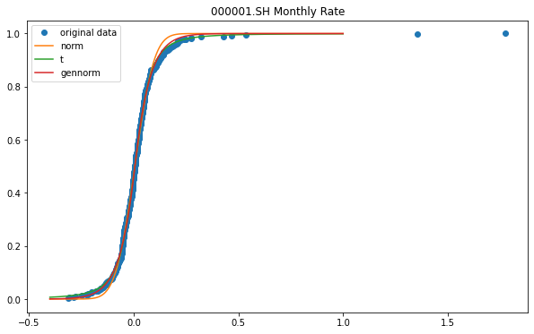

```python
vis_month('000001.SH')
```

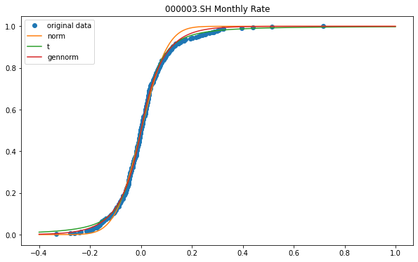

```python
vis_month('000003.SH')
```

### 调用函数vis_month可查看所有指数的月收益率分布的可视化

### 输入一个指数的ts_code，函数vary将展示该指数五年月收益率的特征指数随着时间变化的走向，包括平均值，标准差，峰度，95%VaR值

```python
def vary(ts_code):
    data=data_5y.swaplevel(0,1)[ts_code]
    plt.subplot(221)
    plt.plot(data['mean'],label='mean')
    plt.legend(loc='best')
    plt.subplot(222)
    plt.plot(data['std'],label='std')
    plt.legend(loc='best')
    plt.subplot(223)
    plt.plot(data['kurt'],label='kurt')
    plt.legend(loc='best')
    data=ana_5y.swaplevel(0,1)[ts_code]
    plt.subplot(224)
    plt.plot(data['95%VaR'],label='95%VaR')
    plt.legend(loc='best')
```

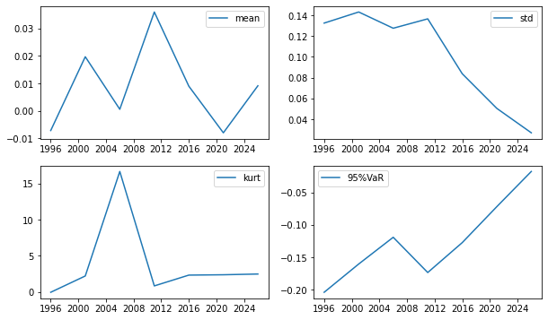

```python
vary('000003.SH')
```

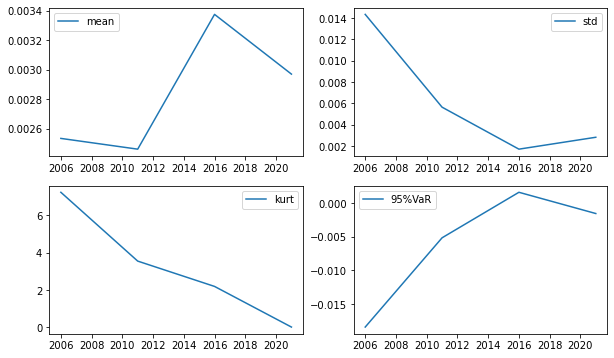

```python
vary('000012.SH')
```

### 调用函数vary可查看所有指数的特征指数走势